# Overview

Dataset info

| Number of variables | 48 |
| --- | --- |
| Number of observations | 19622 |
| Total Missing (%) | 0.0% |
| Total size in memory | 7.2 MiB |
| Average record size in memory | 384.0 B |

Variables types

| Numeric | 48 |
| --- | --- |
| Categorical | 0 |
| Boolean | 0 |
| Date | 0 |
| Text (Unique) | 0 |
| Rejected | 0 |
| Unsupported | 0 |

Warnings

- `gyros_belt_x` is highly skewed (γ1 = 103.01) Skewed

# Variables

accel_arm_x  
Numeric

| Distinct count | 19622 |
| --- | --- |
| Unique (%) | 100.0% |
| Missing (%) | 0.0% |
| Missing (n) | 0 |
| Infinite (%) | 0.0% |
| Infinite (n) | 0 |

| Mean | 1.4485e-18 |
| --- | --- |
| Minimum | -3.3751 |
| Maximum | 16.459 |
| Zeros (%) | 0.0% |

Toggle details

**Statistics**

Quantile statistics

| Minimum | -3.3751 |
| --- | --- |
| 5-th percentile | -1.1378 |
| Q1 | -0.41444 |
| Median | -0.050629 |
| Q3 | 0.42216 |
| 95-th percentile | 1.2935 |
| Maximum | 16.459 |
| Range | 19.834 |
| Interquartile range | 0.83659 |

Descriptive statistics

| Standard deviation | 0.71853 |
| --- | --- |
| Coef of variation | 4.9606e+17 |
| Kurtosis | 14.427 |
| Mean | 1.4485e-18 |
| MAD | 0.54745 |
| Skewness | 0.75799 |
| Sum | 2.8422e-14 |
| Variance | 0.51628 |
| Memory size | 153.4 KiB |

**Histogram**

[figure not shown]

**Common Values**

| Value | Count | Frequency (%) |  |
| --- | --- | --- | --- |
| 1.125019621901172 | 1 | 0.0% |  |
| -0.24908806966558888 | 1 | 0.0% |  |
| 0.6137169089716744 | 1 | 0.0% |  |
| -0.07068034080196729 | 1 | 0.0% |  |
| 0.07525350592639454 | 1 | 0.0% |  |
| -0.39943340896790674 | 1 | 0.0% |  |
| 0.1522103043486649 | 1 | 0.0% |  |
| 0.5802820518443406 | 1 | 0.0% |  |
| -0.6970664853767466 | 1 | 0.0% |  |
| 1.7195274753928178 | 1 | 0.0% |  |
| Other values (19612) | 19612 | 99.9% |  |

**Extreme Values**

Minimum 5 values

| Value | Count | Frequency (%) |  |
| --- | --- | --- | --- |
| -3.3751109643036967 | 1 | 0.0% |  |
| -3.174648514288872 | 1 | 0.0% |  |
| -2.858645808673868 | 1 | 0.0% |  |
| -2.780111293455394 | 1 | 0.0% |  |
| -2.7372916199065234 | 1 | 0.0% |  |

Maximum 5 values

| Value | Count | Frequency (%) |  |
| --- | --- | --- | --- |
| 2.738645171423006 | 1 | 0.0% |  |
| 2.7967402973239945 | 1 | 0.0% |  |
| 3.086728280358063 | 1 | 0.0% |  |
| 3.1441908427309126 | 1 | 0.0% |  |
| 16.459376339956883 | 1 | 0.0% |  |

accel_arm_y  
Numeric

| Distinct count | 19622 |
| --- | --- |
| Unique (%) | 100.0% |
| Missing (%) | 0.0% |
| Missing (n) | 0 |
| Infinite (%) | 0.0% |
| Infinite (n) | 0 |

| Mean | -1.4485e-17 |
| --- | --- |
| Minimum | -2.1783 |
| Maximum | 3.0711 |
| Zeros (%) | 0.0% |

Toggle details

**Statistics**

Quantile statistics

| Minimum | -2.1783 |
| --- | --- |
| 5-th percentile | -1.0404 |
| Q1 | -0.40521 |
| Median | -0.026525 |
| Q3 | 0.41752 |
| 95-th percentile | 1.0333 |
| Maximum | 3.0711 |
| Range | 5.2494 |
| Interquartile range | 0.82272 |

Descriptive statistics

| Standard deviation | 0.6628 |
| --- | --- |
| Coef of variation | -4.5759e+16 |
| Kurtosis | 1.3521 |
| Mean | -1.4485e-17 |
| MAD | 0.50764 |
| Skewness | 0.42029 |
| Sum | -2.8422e-13 |
| Variance | 0.4393 |
| Memory size | 153.4 KiB |

**Histogram**

[figure not shown]

**Common Values**

| Value | Count | Frequency (%) |  |
| --- | --- | --- | --- |
| -0.34811161118767087 | 1 | 0.0% |  |
| 0.5562452498201447 | 1 | 0.0% |  |
| 0.36312176231623544 | 1 | 0.0% |  |
| 0.5484082646120596 | 1 | 0.0% |  |
| -0.7493544782775665 | 1 | 0.0% |  |
| -0.026002557786060167 | 1 | 0.0% |  |
| 1.0834210911677187 | 1 | 0.0% |  |
| -0.4952622279399451 | 1 | 0.0% |  |
| 2.1723482038145625 | 1 | 0.0% |  |
| 0.7619323925202011 | 1 | 0.0% |  |
| Other values (19612) | 19612 | 99.9% |  |

**Extreme Values**

Minimum 5 values

| Value | Count | Frequency (%) |  |
| --- | --- | --- | --- |
| -2.178263965944311 | 1 | 0.0% |  |
| -2.0810361300314075 | 1 | 0.0% |  |
| -2.0453914634702444 | 1 | 0.0% |  |
| -2.0365663538603656 | 1 | 0.0% |  |
| -2.020813296552285 | 1 | 0.0% |  |

Maximum 5 values

| Value | Count | Frequency (%) |  |
| --- | --- | --- | --- |
| 2.9941731731281873 | 1 | 0.0% |  |
| 3.0092807942044066 | 1 | 0.0% |  |
| 3.0153711177606084 | 1 | 0.0% |  |
| 3.020447069941724 | 1 | 0.0% |  |
| 3.071145694511668 | 1 | 0.0% |  |

accel_arm_z  
Numeric

| Distinct count | 19622 |
| --- | --- |
| Unique (%) | 100.0% |
| Missing (%) | 0.0% |
| Missing (n) | 0 |
| Infinite (%) | 0.0% |
| Infinite (n) | 0 |

| Mean | 1.4485e-17 |
| --- | --- |
| Minimum | -2.7189 |
| Maximum | 2.9799 |
| Zeros (%) | 0.0% |

Toggle details

**Statistics**

Quantile statistics

| Minimum | -2.7189 |
| --- | --- |
| 5-th percentile | -0.98804 |
| Q1 | -0.35332 |
| Median | -0.022433 |
| Q3 | 0.3529 |
| 95-th percentile | 1.007 |
| Maximum | 2.9799 |
| Range | 5.6988 |
| Interquartile range | 0.70622 |

Descriptive statistics

| Standard deviation | 0.61778 |
| --- | --- |
| Coef of variation | 4.2651e+16 |
| Kurtosis | 1.454 |
| Mean | 1.4485e-17 |
| MAD | 0.46491 |
| Skewness | 0.16197 |
| Sum | 2.8422e-13 |
| Variance | 0.38166 |
| Memory size | 153.4 KiB |

**Histogram**

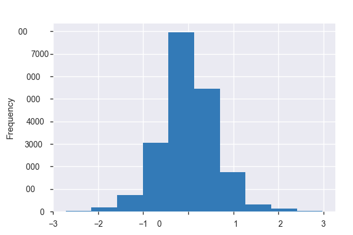

**Common Values**

| Value | Count | Frequency (%) |  |
| --- | --- | --- | --- |
| 0.4480843340242201 | 1 | 0.0% |  |
| 0.16971642703559275 | 1 | 0.0% |  |
| 0.39053125135959416 | 1 | 0.0% |  |
| 0.16459179189958265 | 1 | 0.0% |  |
| 0.1369597124597226 | 1 | 0.0% |  |
| 0.36295370546179007 | 1 | 0.0% |  |
| -0.22840041505182737 | 1 | 0.0% |  |
| 1.000213641857652 | 1 | 0.0% |  |
| 0.5271980343672352 | 1 | 0.0% |  |
| -0.634293639804947 | 1 | 0.0% |  |
| Other values (19612) | 19612 | 99.9% |  |

**Extreme Values**

Minimum 5 values

| Value | Count | Frequency (%) |  |
| --- | --- | --- | --- |
| -2.7188811621111166 | 1 | 0.0% |  |
| -2.7155569888040034 | 1 | 0.0% |  |
| -2.642157937500761 | 1 | 0.0% |  |
| -2.5730375806860897 | 1 | 0.0% |  |
| -2.5454381286626377 | 1 | 0.0% |  |

Maximum 5 values

| Value | Count | Frequency (%) |  |
| --- | --- | --- | --- |
| 2.7413108370963832 | 1 | 0.0% |  |
| 2.7482256233634423 | 1 | 0.0% |  |
| 2.8313525251351397 | 1 | 0.0% |  |
| 2.8533990821179254 | 1 | 0.0% |  |
| 2.979914674419175 | 1 | 0.0% |  |

accel_belt_x  
Numeric

| Distinct count | 19622 |
| --- | --- |
| Unique (%) | 100.0% |
| Missing (%) | 0.0% |
| Missing (n) | 0 |
| Infinite (%) | 0.0% |
| Infinite (n) | 0 |

| Mean | 2.8969e-17 |
| --- | --- |
| Minimum | -4.3821 |
| Maximum | 6.4674 |
| Zeros (%) | 0.0% |

Toggle details

**Statistics**

Quantile statistics

| Minimum | -4.3821 |
| --- | --- |
| 5-th percentile | -2.3526 |
| Q1 | -1.074 |
| Median | 0.0023381 |
| Q3 | 0.9491 |
| 95-th percentile | 2.6059 |
| Maximum | 6.4674 |
| Range | 10.85 |
| Interquartile range | 2.0231 |

Descriptive statistics

| Standard deviation | 1.4805 |
| --- | --- |
| Coef of variation | 5.1107e+16 |
| Kurtosis | -0.05915 |
| Mean | 2.8969e-17 |
| MAD | 1.1673 |
| Skewness | 0.24357 |
| Sum | 5.6843e-13 |
| Variance | 2.1919 |
| Memory size | 153.4 KiB |

**Histogram**

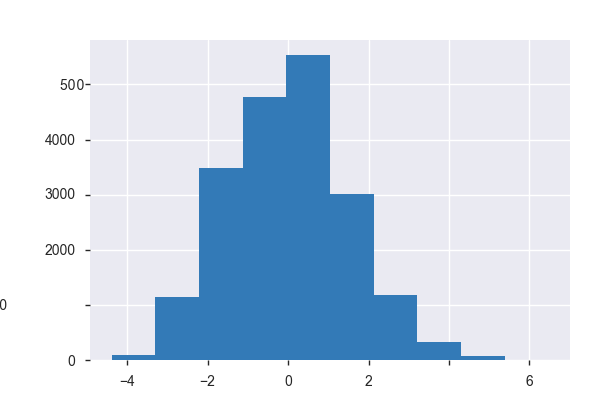

**Common Values**

| Value | Count | Frequency (%) |  |
| --- | --- | --- | --- |
| 0.9002387625047973 | 1 | 0.0% |  |
| -1.3307996263191824 | 1 | 0.0% |  |
| 1.2549487580786656 | 1 | 0.0% |  |
| 0.1022796127471889 | 1 | 0.0% |  |
| -0.30131821639780215 | 1 | 0.0% |  |
| 0.3020129988603702 | 1 | 0.0% |  |
| -0.2561646079677771 | 1 | 0.0% |  |
| -1.6283496895255278 | 1 | 0.0% |  |
| -1.3917293249383453 | 1 | 0.0% |  |
| 1.2097778058736846 | 1 | 0.0% |  |
| Other values (19612) | 19612 | 99.9% |  |

**Extreme Values**

Minimum 5 values

| Value | Count | Frequency (%) |  |
| --- | --- | --- | --- |
| -4.382102680585709 | 1 | 0.0% |  |
| -4.349865949198513 | 1 | 0.0% |  |
| -4.309176704907064 | 1 | 0.0% |  |
| -4.292428371337884 | 1 | 0.0% |  |
| -4.278950212474131 | 1 | 0.0% |  |

Maximum 5 values

| Value | Count | Frequency (%) |  |
| --- | --- | --- | --- |
| 5.3099332244594235 | 1 | 0.0% |  |
| 5.365169859446578 | 1 | 0.0% |  |
| 5.415952122609617 | 1 | 0.0% |  |
| 5.447611067693188 | 1 | 0.0% |  |
| 6.467400532266996 | 1 | 0.0% |  |

accel_belt_y  
Numeric

| Distinct count | 19622 |
| --- | --- |
| Unique (%) | 100.0% |
| Missing (%) | 0.0% |
| Missing (n) | 0 |
| Infinite (%) | 0.0% |
| Infinite (n) | 0 |

| Mean | -5.7938e-18 |
| --- | --- |
| Minimum | -4.2724 |
| Maximum | 6.301 |
| Zeros (%) | 0.0% |

Toggle details

**Statistics**

Quantile statistics

| Minimum | -4.2724 |
| --- | --- |
| 5-th percentile | -2.3331 |
| Q1 | -0.93262 |
| Median | 0.048757 |
| Q3 | 0.85436 |
| 95-th percentile | 2.2843 |
| Maximum | 6.301 |
| Range | 10.573 |
| Interquartile range | 1.787 |

Descriptive statistics

| Standard deviation | 1.365 |
| --- | --- |
| Coef of variation | -2.3559e+17 |
| Kurtosis | -0.030183 |
| Mean | -5.7938e-18 |
| MAD | 1.0792 |
| Skewness | 0.0057456 |
| Sum | -1.1369e-13 |
| Variance | 1.8631 |
| Memory size | 153.4 KiB |

**Histogram**

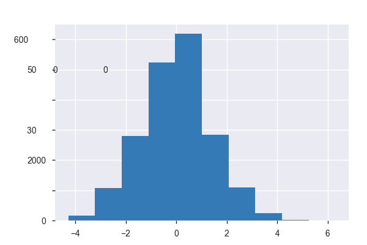

**Common Values**

| Value | Count | Frequency (%) |  |
| --- | --- | --- | --- |
| 1.4897355743121932 | 1 | 0.0% |  |
| 1.4243705703369967 | 1 | 0.0% |  |
| -0.8565124778974249 | 1 | 0.0% |  |
| 0.9215755897638754 | 1 | 0.0% |  |
| 0.17339409784499044 | 1 | 0.0% |  |
| -1.9890024815378675 | 1 | 0.0% |  |
| 0.5452802660134717 | 1 | 0.0% |  |
| -2.0513116693262865 | 1 | 0.0% |  |
| 1.6325662851647638 | 1 | 0.0% |  |
| -0.2407666702732953 | 1 | 0.0% |  |
| Other values (19612) | 19612 | 99.9% |  |

**Extreme Values**

Minimum 5 values

| Value | Count | Frequency (%) |  |
| --- | --- | --- | --- |
| -4.272367187604876 | 1 | 0.0% |  |
| -4.073861073231077 | 1 | 0.0% |  |
| -4.003267217529499 | 1 | 0.0% |  |
| -3.9428518696096195 | 1 | 0.0% |  |
| -3.9221024064344285 | 1 | 0.0% |  |

Maximum 5 values

| Value | Count | Frequency (%) |  |
| --- | --- | --- | --- |
| 4.565068765574692 | 1 | 0.0% |  |
| 4.578418390015987 | 1 | 0.0% |  |
| 4.588916552121852 | 1 | 0.0% |  |
| 4.690344575967332 | 1 | 0.0% |  |
| 6.300961575822415 | 1 | 0.0% |  |

accel_belt_z  
Numeric

| Distinct count | 19622 |
| --- | --- |
| Unique (%) | 100.0% |
| Missing (%) | 0.0% |
| Missing (n) | 0 |
| Infinite (%) | 0.0% |
| Infinite (n) | 0 |

| Mean | -7.2423e-18 |
| --- | --- |
| Minimum | -3.9123 |
| Maximum | 4.7034 |
| Zeros (%) | 0.0% |

Toggle details

**Statistics**

Quantile statistics

| Minimum | -3.9123 |
| --- | --- |
| 5-th percentile | -2.1816 |
| Q1 | -0.93721 |
| Median | 0.051077 |
| Q3 | 0.91711 |
| 95-th percentile | 2.0432 |
| Maximum | 4.7034 |
| Range | 8.6157 |
| Interquartile range | 1.8543 |

Descriptive statistics

| Standard deviation | 1.2786 |
| --- | --- |
| Coef of variation | -1.7654e+17 |
| Kurtosis | -0.27064 |
| Mean | -7.2423e-18 |
| MAD | 1.0437 |
| Skewness | -0.013857 |
| Sum | -1.4211e-13 |
| Variance | 1.6347 |
| Memory size | 153.4 KiB |

**Histogram**

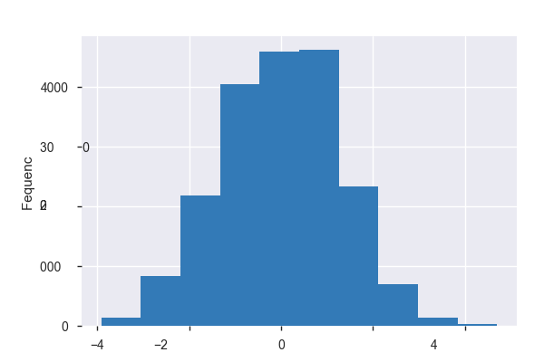

**Common Values**

| Value | Count | Frequency (%) |  |
| --- | --- | --- | --- |
| 1.1604928349451773 | 1 | 0.0% |  |
| -0.8430279008691597 | 1 | 0.0% |  |
| 1.0349742645588431 | 1 | 0.0% |  |
| 0.9749062487653357 | 1 | 0.0% |  |
| 0.6974212645178228 | 1 | 0.0% |  |
| -0.8405461992272352 | 1 | 0.0% |  |
| -0.9283098856453856 | 1 | 0.0% |  |
| -2.0284394475374943 | 1 | 0.0% |  |
| 0.19774811386833566 | 1 | 0.0% |  |
| 1.1029272994719996 | 1 | 0.0% |  |
| Other values (19612) | 19612 | 99.9% |  |

**Extreme Values**

Minimum 5 values

| Value | Count | Frequency (%) |  |
| --- | --- | --- | --- |
| -3.912304832450461 | 1 | 0.0% |  |
| -3.797441645661689 | 1 | 0.0% |  |
| -3.7387085024648523 | 1 | 0.0% |  |
| -3.727950060585056 | 1 | 0.0% |  |
| -3.6950812230709547 | 1 | 0.0% |  |

Maximum 5 values

| Value | Count | Frequency (%) |  |
| --- | --- | --- | --- |
| 4.487281174649186 | 1 | 0.0% |  |
| 4.4875501556591075 | 1 | 0.0% |  |
| 4.587159817079729 | 1 | 0.0% |  |
| 4.64320072394884 | 1 | 0.0% |  |
| 4.703426320119345 | 1 | 0.0% |  |

accel_dumbbell_x  
Numeric

| Distinct count | 19622 |
| --- | --- |
| Unique (%) | 100.0% |
| Missing (%) | 0.0% |
| Missing (n) | 0 |
| Infinite (%) | 0.0% |
| Infinite (n) | 0 |

| Mean | 3.0418e-17 |
| --- | --- |
| Minimum | -3.1098 |
| Maximum | 4.3848 |
| Zeros (%) | 0.0% |

Toggle details

**Statistics**

Quantile statistics

| Minimum | -3.1098 |
| --- | --- |
| 5-th percentile | -0.53458 |
| Q1 | -0.18314 |
| Median | -0.00182 |
| Q3 | 0.17523 |
| 95-th percentile | 0.53021 |
| Maximum | 4.3848 |
| Range | 7.4946 |
| Interquartile range | 0.35837 |

Descriptive statistics

| Standard deviation | 0.34341 |
| --- | --- |
| Coef of variation | 1.129e+16 |
| Kurtosis | 8.3056 |
| Mean | 3.0418e-17 |
| MAD | 0.24499 |
| Skewness | 0.56541 |
| Sum | 5.9686e-13 |
| Variance | 0.11793 |
| Memory size | 153.4 KiB |

**Histogram**

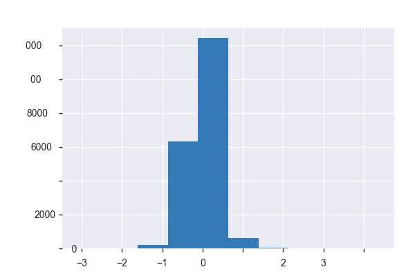

**Common Values**

| Value | Count | Frequency (%) |  |
| --- | --- | --- | --- |
| 0.39950713136561905 | 1 | 0.0% |  |
| -0.00032501796466951287 | 1 | 0.0% |  |
| 1.26364117954522 | 1 | 0.0% |  |
| 0.4588421428491919 | 1 | 0.0% |  |
| -0.4019789339544526 | 1 | 0.0% |  |
| 0.23575980304472638 | 1 | 0.0% |  |
| 0.6798406254171011 | 1 | 0.0% |  |
| 0.022181039652665366 | 1 | 0.0% |  |
| 0.45033086093379376 | 1 | 0.0% |  |
| -0.17060530797485848 | 1 | 0.0% |  |
| Other values (19612) | 19612 | 99.9% |  |

**Extreme Values**

Minimum 5 values

| Value | Count | Frequency (%) |  |
| --- | --- | --- | --- |
| -3.109783235309904 | 1 | 0.0% |  |
| -2.1261046233697636 | 1 | 0.0% |  |
| -1.945291032974246 | 1 | 0.0% |  |
| -1.9072593730791587 | 1 | 0.0% |  |
| -1.9013724609792573 | 1 | 0.0% |  |

Maximum 5 values

| Value | Count | Frequency (%) |  |
| --- | --- | --- | --- |
| 3.091497827230574 | 1 | 0.0% |  |
| 3.91449544114656 | 1 | 0.0% |  |
| 4.2373520164342775 | 1 | 0.0% |  |
| 4.294713426115536 | 1 | 0.0% |  |
| 4.384807152712143 | 1 | 0.0% |  |

accel_dumbbell_y  
Numeric

| Distinct count | 19622 |
| --- | --- |
| Unique (%) | 100.0% |
| Missing (%) | 0.0% |
| Missing (n) | 0 |
| Infinite (%) | 0.0% |
| Infinite (n) | 0 |

| Mean | 8.6908e-18 |
| --- | --- |
| Minimum | -1.6756 |
| Maximum | 1.6804 |
| Zeros (%) | 0.0% |

Toggle details

**Statistics**

Quantile statistics

| Minimum | -1.6756 |
| --- | --- |
| 5-th percentile | -0.52085 |
| Q1 | -0.1737 |
| Median | 0.0098589 |
| Q3 | 0.18212 |
| 95-th percentile | 0.43913 |
| Maximum | 1.6804 |
| Range | 3.356 |
| Interquartile range | 0.35582 |

Descriptive statistics

| Standard deviation | 0.31765 |
| --- | --- |
| Coef of variation | 3.655e+16 |
| Kurtosis | 2.7835 |
| Mean | 8.6908e-18 |
| MAD | 0.23335 |
| Skewness | 0.077926 |
| Sum | 1.7053e-13 |
| Variance | 0.1009 |
| Memory size | 153.4 KiB |

**Histogram**

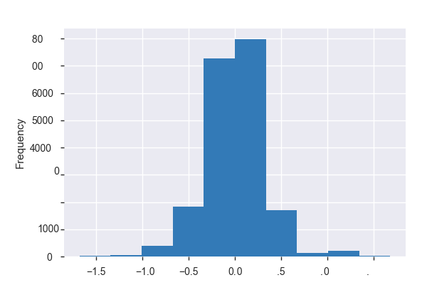

**Common Values**

| Value | Count | Frequency (%) |  |
| --- | --- | --- | --- |
| 0.30408345230466133 | 1 | 0.0% |  |
| -0.1086952899254453 | 1 | 0.0% |  |
| 0.0361973692473022 | 1 | 0.0% |  |
| 0.2157181057660057 | 1 | 0.0% |  |
| 0.335459338907351 | 1 | 0.0% |  |
| -0.04563999695164281 | 1 | 0.0% |  |
| -0.13663813741781985 | 1 | 0.0% |  |
| -0.15061929827596107 | 1 | 0.0% |  |
| -0.010705704295125709 | 1 | 0.0% |  |
| 0.13242335093800228 | 1 | 0.0% |  |
| Other values (19612) | 19612 | 99.9% |  |

**Extreme Values**

Minimum 5 values

| Value | Count | Frequency (%) |  |
| --- | --- | --- | --- |
| -1.6755542254072537 | 1 | 0.0% |  |
| -1.653821282563006 | 1 | 0.0% |  |
| -1.5897446208194326 | 1 | 0.0% |  |
| -1.5820614599875857 | 1 | 0.0% |  |
| -1.5732106850968217 | 1 | 0.0% |  |

Maximum 5 values

| Value | Count | Frequency (%) |  |
| --- | --- | --- | --- |
| 1.5313164547209006 | 1 | 0.0% |  |
| 1.6409041084490668 | 1 | 0.0% |  |
| 1.6473875502883493 | 1 | 0.0% |  |
| 1.6743551774541874 | 1 | 0.0% |  |
| 1.6804491399792638 | 1 | 0.0% |  |

accel_dumbbell_z  
Numeric

| Distinct count | 19622 |
| --- | --- |
| Unique (%) | 100.0% |
| Missing (%) | 0.0% |
| Missing (n) | 0 |
| Infinite (%) | 0.0% |
| Infinite (n) | 0 |

| Mean | 0 |
| --- | --- |
| Minimum | -1.6166 |
| Maximum | 3.3954 |
| Zeros (%) | 0.0% |

Toggle details

**Statistics**

Quantile statistics

| Minimum | -1.6166 |
| --- | --- |
| 5-th percentile | -0.44743 |
| Q1 | -0.18103 |
| Median | -0.014514 |
| Q3 | 0.17696 |
| 95-th percentile | 0.47514 |
| Maximum | 3.3954 |
| Range | 5.012 |
| Interquartile range | 0.35799 |

Descriptive statistics

| Standard deviation | 0.289 |
| --- | --- |
| Coef of variation |  |
| Kurtosis | 2.8393 |
| Mean | 0 |
| MAD | 0.22166 |
| Skewness | 0.43827 |
| Sum | 0 |
| Variance | 0.08352 |
| Memory size | 153.4 KiB |

**Histogram**

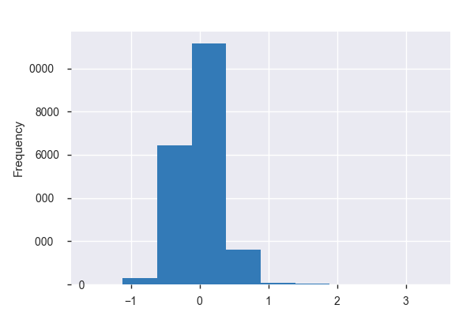

**Common Values**

| Value | Count | Frequency (%) |  |
| --- | --- | --- | --- |
| 0.1316714515888485 | 1 | 0.0% |  |
| -0.3573320912224405 | 1 | 0.0% |  |
| -0.4631803621836148 | 1 | 0.0% |  |
| 0.20263963671557364 | 1 | 0.0% |  |
| -0.10933557807964249 | 1 | 0.0% |  |
| -0.35498947731921915 | 1 | 0.0% |  |
| -0.1031705537018525 | 1 | 0.0% |  |
| 0.43377239375382254 | 1 | 0.0% |  |
| -0.24224044853033505 | 1 | 0.0% |  |
| -0.1341317168176452 | 1 | 0.0% |  |
| Other values (19612) | 19612 | 99.9% |  |

**Extreme Values**

Minimum 5 values

| Value | Count | Frequency (%) |  |
| --- | --- | --- | --- |
| -1.616586354324696 | 1 | 0.0% |  |
| -1.1191416132417715 | 1 | 0.0% |  |
| -1.0986444909301052 | 1 | 0.0% |  |
| -1.0933246496233486 | 1 | 0.0% |  |
| -1.0863107774220344 | 1 | 0.0% |  |

Maximum 5 values

| Value | Count | Frequency (%) |  |
| --- | --- | --- | --- |
| 1.8550562393786683 | 1 | 0.0% |  |
| 2.223943689438122 | 1 | 0.0% |  |
| 2.288796375236874 | 1 | 0.0% |  |
| 2.3501847488684287 | 1 | 0.0% |  |
| 3.3954208255925247 | 1 | 0.0% |  |

accel_forearm_x  
Numeric

| Distinct count | 19622 |
| --- | --- |
| Unique (%) | 100.0% |
| Missing (%) | 0.0% |
| Missing (n) | 0 |
| Infinite (%) | 0.0% |
| Infinite (n) | 0 |

| Mean | 2.0278e-17 |
| --- | --- |
| Minimum | -0.84583 |
| Maximum | 1.121 |
| Zeros (%) | 0.0% |

Toggle details

**Statistics**

Quantile statistics

| Minimum | -0.84583 |
| --- | --- |
| 5-th percentile | -0.22643 |
| Q1 | -0.094934 |
| Median | -0.0082451 |
| Q3 | 0.079188 |
| 95-th percentile | 0.27249 |
| Maximum | 1.121 |
| Range | 1.9668 |
| Interquartile range | 0.17412 |

Descriptive statistics

| Standard deviation | 0.15595 |
| --- | --- |
| Coef of variation | 7690400000000000 |
| Kurtosis | 2.6373 |
| Mean | 2.0278e-17 |
| MAD | 0.11491 |
| Skewness | 0.53781 |
| Sum | 3.979e-13 |
| Variance | 0.02432 |
| Memory size | 153.4 KiB |

**Histogram**

[figure not shown]

**Common Values**

| Value | Count | Frequency (%) |  |
| --- | --- | --- | --- |
| 0.004916135011702522 | 1 | 0.0% |  |
| -0.19396437834804847 | 1 | 0.0% |  |
| -0.10402153506582001 | 1 | 0.0% |  |
| -0.0036952338876679374 | 1 | 0.0% |  |
| 0.023302205340276223 | 1 | 0.0% |  |
| -0.0023568473696211644 | 1 | 0.0% |  |
| 0.01912285716144925 | 1 | 0.0% |  |
| -0.0878450514128008 | 1 | 0.0% |  |
| 0.303303151073484 | 1 | 0.0% |  |
| -0.02143696268183496 | 1 | 0.0% |  |
| Other values (19612) | 19612 | 99.9% |  |

**Extreme Values**

Minimum 5 values

| Value | Count | Frequency (%) |  |
| --- | --- | --- | --- |
| -0.8458289795441933 | 1 | 0.0% |  |
| -0.7852875452141861 | 1 | 0.0% |  |
| -0.7771478480019228 | 1 | 0.0% |  |
| -0.7743673155421269 | 1 | 0.0% |  |
| -0.7627736120065376 | 1 | 0.0% |  |

Maximum 5 values

| Value | Count | Frequency (%) |  |
| --- | --- | --- | --- |
| 0.8934699355336501 | 1 | 0.0% |  |
| 0.9170763302591729 | 1 | 0.0% |  |
| 0.9448197650699067 | 1 | 0.0% |  |
| 0.9520489010686699 | 1 | 0.0% |  |
| 1.1209786535735844 | 1 | 0.0% |  |

accel_forearm_y  
Numeric

| Distinct count | 19622 |
| --- | --- |
| Unique (%) | 100.0% |
| Missing (%) | 0.0% |
| Missing (n) | 0 |
| Infinite (%) | 0.0% |
| Infinite (n) | 0 |

| Mean | 3.0418e-17 |
| --- | --- |
| Minimum | -0.97794 |
| Maximum | 1.3623 |
| Zeros (%) | 0.0% |

Toggle details

**Statistics**

Quantile statistics

| Minimum | -0.97794 |
| --- | --- |
| 5-th percentile | -0.21861 |
| Q1 | -0.080238 |
| Median | -0.0063624 |
| Q3 | 0.074082 |
| 95-th percentile | 0.24345 |
| Maximum | 1.3623 |
| Range | 2.3402 |
| Interquartile range | 0.15432 |

Descriptive statistics

| Standard deviation | 0.14914 |
| --- | --- |
| Coef of variation | 4903200000000000 |
| Kurtosis | 4.0372 |
| Mean | 3.0418e-17 |
| MAD | 0.10662 |
| Skewness | 0.39424 |
| Sum | 5.9686e-13 |
| Variance | 0.022244 |
| Memory size | 153.4 KiB |

**Histogram**

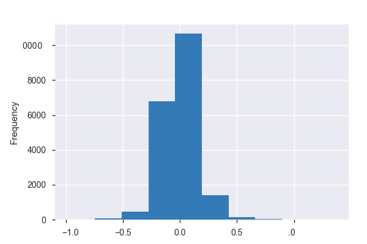

**Common Values**

| Value | Count | Frequency (%) |  |
| --- | --- | --- | --- |
| -0.002801589144470631 | 1 | 0.0% |  |
| 0.13937206476294572 | 1 | 0.0% |  |
| -0.014786673502474276 | 1 | 0.0% |  |
| 0.015717970203189754 | 1 | 0.0% |  |
| -0.07437706935527684 | 1 | 0.0% |  |
| -0.12793192784262694 | 1 | 0.0% |  |
| 0.1956404364199147 | 1 | 0.0% |  |
| -0.031059887336140873 | 1 | 0.0% |  |
| 0.013443917664285715 | 1 | 0.0% |  |
| -0.16874335153885636 | 1 | 0.0% |  |
| Other values (19612) | 19612 | 99.9% |  |

**Extreme Values**

Minimum 5 values

| Value | Count | Frequency (%) |  |
| --- | --- | --- | --- |
| -0.9779362917609697 | 1 | 0.0% |  |
| -0.9071455901935191 | 1 | 0.0% |  |
| -0.906969235602885 | 1 | 0.0% |  |
| -0.8936629737833826 | 1 | 0.0% |  |
| -0.8480001878026427 | 1 | 0.0% |  |

Maximum 5 values

| Value | Count | Frequency (%) |  |
| --- | --- | --- | --- |
| 0.9448521355198032 | 1 | 0.0% |  |
| 0.9814685634304685 | 1 | 0.0% |  |
| 1.042857969287426 | 1 | 0.0% |  |
| 1.1576007171670712 | 1 | 0.0% |  |
| 1.3622840965886354 | 1 | 0.0% |  |

accel_forearm_z  
Numeric

| Distinct count | 19622 |
| --- | --- |
| Unique (%) | 100.0% |
| Missing (%) | 0.0% |
| Missing (n) | 0 |
| Infinite (%) | 0.0% |
| Infinite (n) | 0 |

| Mean | 1.883e-17 |
| --- | --- |
| Minimum | -1.3691 |
| Maximum | 2.1984 |
| Zeros (%) | 0.0% |

Toggle details

**Statistics**

Quantile statistics

| Minimum | -1.3691 |
| --- | --- |
| 5-th percentile | -0.17533 |
| Q1 | -0.062273 |
| Median | -0.0048964 |
| Q3 | 0.052237 |
| 95-th percentile | 0.17647 |
| Maximum | 2.1984 |
| Range | 3.5675 |
| Interquartile range | 0.11451 |

Descriptive statistics

| Standard deviation | 0.13869 |
| --- | --- |
| Coef of variation | 7365600000000000 |
| Kurtosis | 44.211 |
| Mean | 1.883e-17 |
| MAD | 0.083286 |
| Skewness | 3.4988 |
| Sum | 3.6948e-13 |
| Variance | 0.019236 |
| Memory size | 153.4 KiB |

**Histogram**

[figure not shown]

**Common Values**

| Value | Count | Frequency (%) |  |
| --- | --- | --- | --- |
| -0.1629121936083815 | 1 | 0.0% |  |
| -0.20132096790735013 | 1 | 0.0% |  |
| -0.11604122442775824 | 1 | 0.0% |  |
| 0.006936449938214039 | 1 | 0.0% |  |
| 0.13899062248139735 | 1 | 0.0% |  |
| -0.03592253776612668 | 1 | 0.0% |  |
| -0.1323419810485819 | 1 | 0.0% |  |
| 0.04845684987393969 | 1 | 0.0% |  |
| -0.07020978669734332 | 1 | 0.0% |  |
| -0.07788052652846567 | 1 | 0.0% |  |
| Other values (19612) | 19612 | 99.9% |  |

**Extreme Values**

Minimum 5 values

| Value | Count | Frequency (%) |  |
| --- | --- | --- | --- |
| -1.3690811805693823 | 1 | 0.0% |  |
| -1.2566015743451944 | 1 | 0.0% |  |
| -1.2413707898110358 | 1 | 0.0% |  |
| -1.2140315060155835 | 1 | 0.0% |  |
| -1.1825593197216284 | 1 | 0.0% |  |

Maximum 5 values

| Value | Count | Frequency (%) |  |
| --- | --- | --- | --- |
| 1.6225094618229519 | 1 | 0.0% |  |
| 1.6254729639555527 | 1 | 0.0% |  |
| 1.7274218056923225 | 1 | 0.0% |  |
| 1.8040468256813622 | 1 | 0.0% |  |
| 2.198397960267797 | 1 | 0.0% |  |

gyros_arm_x  
Numeric

| Distinct count | 19622 |
| --- | --- |
| Unique (%) | 100.0% |
| Missing (%) | 0.0% |
| Missing (n) | 0 |
| Infinite (%) | 0.0% |
| Infinite (n) | 0 |

| Mean | 6.0835e-17 |
| --- | --- |
| Minimum | -3.9484 |
| Maximum | 4.2825 |
| Zeros (%) | 0.0% |

Toggle details

**Statistics**

Quantile statistics

| Minimum | -3.9484 |
| --- | --- |
| 5-th percentile | -1.3279 |
| Q1 | -0.57736 |
| Median | 0.01586 |
| Q3 | 0.47269 |
| 95-th percentile | 1.3899 |
| Maximum | 4.2825 |
| Range | 8.2309 |
| Interquartile range | 1.05 |

Descriptive statistics

| Standard deviation | 0.85458 |
| --- | --- |
| Coef of variation | 1.4047e+16 |
| Kurtosis | 1.1006 |
| Mean | 6.0835e-17 |
| MAD | 0.65655 |
| Skewness | 0.23027 |
| Sum | 1.1937e-12 |
| Variance | 0.73031 |
| Memory size | 153.4 KiB |

**Histogram**

[figure not shown]

**Common Values**

| Value | Count | Frequency (%) |  |
| --- | --- | --- | --- |
| -1.220255753148019 | 1 | 0.0% |  |
| -1.3946821329215127 | 1 | 0.0% |  |
| 0.09754984749948942 | 1 | 0.0% |  |
| -0.5801889881368587 | 1 | 0.0% |  |
| 0.495763986161465 | 1 | 0.0% |  |
| 0.6477882578226128 | 1 | 0.0% |  |
| 0.35447489756059697 | 1 | 0.0% |  |
| 0.4675397892995622 | 1 | 0.0% |  |
| -0.8415866525555624 | 1 | 0.0% |  |
| -0.852729672025323 | 1 | 0.0% |  |
| Other values (19612) | 19612 | 99.9% |  |

**Extreme Values**

Minimum 5 values

| Value | Count | Frequency (%) |  |
| --- | --- | --- | --- |
| -3.9483734811457047 | 1 | 0.0% |  |
| -3.926308513896684 | 1 | 0.0% |  |
| -3.926074193355088 | 1 | 0.0% |  |
| -3.5927617049299547 | 1 | 0.0% |  |
| -3.584639893859606 | 1 | 0.0% |  |

Maximum 5 values

| Value | Count | Frequency (%) |  |
| --- | --- | --- | --- |
| 4.066294383731685 | 1 | 0.0% |  |
| 4.112916578369447 | 1 | 0.0% |  |
| 4.140596519794833 | 1 | 0.0% |  |
| 4.198050759676918 | 1 | 0.0% |  |
| 4.2825390217227906 | 1 | 0.0% |  |

gyros_arm_y  
Numeric

| Distinct count | 19622 |
| --- | --- |
| Unique (%) | 100.0% |
| Missing (%) | 0.0% |
| Missing (n) | 0 |
| Infinite (%) | 0.0% |
| Infinite (n) | 0 |

| Mean | 4.3454e-18 |
| --- | --- |
| Minimum | -3.6981 |
| Maximum | 11.987 |
| Zeros (%) | 0.0% |

Toggle details

**Statistics**

Quantile statistics

| Minimum | -3.6981 |
| --- | --- |
| 5-th percentile | -1.2791 |
| Q1 | -0.48376 |
| Median | 0.021813 |
| Q3 | 0.48714 |
| 95-th percentile | 1.2906 |
| Maximum | 11.987 |
| Range | 15.685 |
| Interquartile range | 0.97089 |

Descriptive statistics

| Standard deviation | 0.78272 |
| --- | --- |
| Coef of variation | 1.8013e+17 |
| Kurtosis | 3.2942 |
| Mean | 4.3454e-18 |
| MAD | 0.60194 |
| Skewness | 0.17687 |
| Sum | 8.5265e-14 |
| Variance | 0.61265 |
| Memory size | 153.4 KiB |

**Histogram**

[figure not shown]

**Common Values**

| Value | Count | Frequency (%) |  |
| --- | --- | --- | --- |
| -0.44548278094382854 | 1 | 0.0% |  |
| -0.10424252075957761 | 1 | 0.0% |  |
| 0.8864454375910819 | 1 | 0.0% |  |
| -0.4295740441541202 | 1 | 0.0% |  |
| 0.02361655128785376 | 1 | 0.0% |  |
| 1.626031376424264 | 1 | 0.0% |  |
| 1.3330830148615378 | 1 | 0.0% |  |
| 0.8400566648531962 | 1 | 0.0% |  |
| -0.06508305674975087 | 1 | 0.0% |  |
| 0.42316249407866824 | 1 | 0.0% |  |
| Other values (19612) | 19612 | 99.9% |  |

**Extreme Values**

Minimum 5 values

| Value | Count | Frequency (%) |  |
| --- | --- | --- | --- |
| -3.6980530945447567 | 1 | 0.0% |  |
| -3.345316445852535 | 1 | 0.0% |  |
| -3.2238497152419243 | 1 | 0.0% |  |
| -3.0528300626261764 | 1 | 0.0% |  |
| -3.0143514869306967 | 1 | 0.0% |  |

Maximum 5 values

| Value | Count | Frequency (%) |  |
| --- | --- | --- | --- |
| 2.7602278345963276 | 1 | 0.0% |  |
| 2.9712669377568153 | 1 | 0.0% |  |
| 3.0242726953499393 | 1 | 0.0% |  |
| 3.335900170035355 | 1 | 0.0% |  |
| 11.98703527865718 | 1 | 0.0% |  |

gyros_arm_z  
Numeric

| Distinct count | 19622 |
| --- | --- |
| Unique (%) | 100.0% |
| Missing (%) | 0.0% |
| Missing (n) | 0 |
| Infinite (%) | 0.0% |
| Infinite (n) | 0 |

| Mean | 2.8969e-18 |
| --- | --- |
| Minimum | -2.9239 |
| Maximum | 3.5093 |
| Zeros (%) | 0.0% |

Toggle details

**Statistics**

Quantile statistics

| Minimum | -2.9239 |
| --- | --- |
| 5-th percentile | -1.1931 |
| Q1 | -0.51343 |
| Median | 0.011068 |
| Q3 | 0.48681 |
| 95-th percentile | 1.219 |
| Maximum | 3.5093 |
| Range | 6.4332 |
| Interquartile range | 1.0002 |

Descriptive statistics

| Standard deviation | 0.73538 |
| --- | --- |
| Coef of variation | 2.5385e+17 |
| Kurtosis | 0.095766 |
| Mean | 2.8969e-18 |
| MAD | 0.58682 |
| Skewness | 0.11121 |
| Sum | 5.6843e-14 |
| Variance | 0.54078 |
| Memory size | 153.4 KiB |

**Histogram**

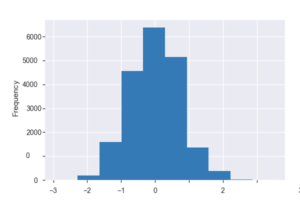

**Common Values**

| Value | Count | Frequency (%) |  |
| --- | --- | --- | --- |
| 0.28971797257774234 | 1 | 0.0% |  |
| 1.2237776339246982 | 1 | 0.0% |  |
| 0.3018159564048079 | 1 | 0.0% |  |
| 0.44532236135061254 | 1 | 0.0% |  |
| -0.7218358045793597 | 1 | 0.0% |  |
| -0.6132314285791086 | 1 | 0.0% |  |
| 0.5179318264286052 | 1 | 0.0% |  |
| -0.46137746599955237 | 1 | 0.0% |  |
| 0.20631172438770792 | 1 | 0.0% |  |
| 0.23135089749317353 | 1 | 0.0% |  |
| Other values (19612) | 19612 | 99.9% |  |

**Extreme Values**

Minimum 5 values

| Value | Count | Frequency (%) |  |
| --- | --- | --- | --- |
| -2.9238729158998527 | 1 | 0.0% |  |
| -2.874944853363892 | 1 | 0.0% |  |
| -2.7075991739989496 | 1 | 0.0% |  |
| -2.4353307739512773 | 1 | 0.0% |  |
| -2.4328770960024997 | 1 | 0.0% |  |

Maximum 5 values

| Value | Count | Frequency (%) |  |
| --- | --- | --- | --- |
| 3.281514019294717 | 1 | 0.0% |  |
| 3.319543965476857 | 1 | 0.0% |  |
| 3.3886607771463373 | 1 | 0.0% |  |
| 3.3914911410258064 | 1 | 0.0% |  |
| 3.509349536135319 | 1 | 0.0% |  |

gyros_belt_x  
Numeric

| Distinct count | 19622 |
| --- | --- |
| Unique (%) | 100.0% |
| Missing (%) | 0.0% |
| Missing (n) | 0 |
| Infinite (%) | 0.0% |
| Infinite (n) | 0 |

| Mean | 2.8969e-17 |
| --- | --- |
| Minimum | -3.6547 |
| Maximum | 256.69 |
| Zeros (%) | 0.0% |

Toggle details

**Statistics**

Quantile statistics

| Minimum | -3.6547 |
| --- | --- |
| 5-th percentile | -1.5929 |
| Q1 | -0.53681 |
| Median | 0.10284 |
| Q3 | 0.57731 |
| 95-th percentile | 1.207 |
| Maximum | 256.69 |
| Range | 260.35 |
| Interquartile range | 1.1141 |

Descriptive statistics

| Standard deviation | 2.03 |
| --- | --- |
| Coef of variation | 7.0073e+16 |
| Kurtosis | 13032 |
| Mean | 2.8969e-17 |
| MAD | 0.69696 |
| Skewness | 103.01 |
| Sum | 5.6843e-13 |
| Variance | 4.1208 |
| Memory size | 153.4 KiB |

**Histogram**

[figure not shown]

**Common Values**

| Value | Count | Frequency (%) |  |
| --- | --- | --- | --- |
| -2.5535583431493656 | 1 | 0.0% |  |
| -0.8927354958141929 | 1 | 0.0% |  |
| -0.19629377880234786 | 1 | 0.0% |  |
| -0.5069137356244487 | 1 | 0.0% |  |
| -1.4336547293748254 | 1 | 0.0% |  |
| 0.47180821494936065 | 1 | 0.0% |  |
| 1.2643492715274554 | 1 | 0.0% |  |
| 0.2650412578827879 | 1 | 0.0% |  |
| -0.55955748098521 | 1 | 0.0% |  |
| 1.1292825058673155 | 1 | 0.0% |  |
| Other values (19612) | 19612 | 99.9% |  |

**Extreme Values**

Minimum 5 values

| Value | Count | Frequency (%) |  |
| --- | --- | --- | --- |
| -3.654667774449002 | 1 | 0.0% |  |
| -3.6201916948951527 | 1 | 0.0% |  |
| -3.6029637369851155 | 1 | 0.0% |  |
| -3.5166050062426106 | 1 | 0.0% |  |
| -3.4799585174855205 | 1 | 0.0% |  |

Maximum 5 values

| Value | Count | Frequency (%) |  |
| --- | --- | --- | --- |
| 3.004947851625516 | 1 | 0.0% |  |
| 3.015437242992966 | 1 | 0.0% |  |
| 3.131333787278334 | 1 | 0.0% |  |
| 3.1496966572128446 | 1 | 0.0% |  |
| 256.69199088207705 | 1 | 0.0% |  |

gyros_belt_y  
Numeric

| Distinct count | 19622 |
| --- | --- |
| Unique (%) | 100.0% |
| Missing (%) | 0.0% |
| Missing (n) | 0 |
| Infinite (%) | 0.0% |
| Infinite (n) | 0 |

| Mean | -5.7938e-18 |
| --- | --- |
| Minimum | -4.3532 |
| Maximum | 7.1715 |
| Zeros (%) | 0.0% |

Toggle details

**Statistics**

Quantile statistics

| Minimum | -4.3532 |
| --- | --- |
| 5-th percentile | -2.7294 |
| Q1 | -1.3396 |
| Median | -0.20457 |
| Q3 | 1.1085 |
| 95-th percentile | 3.6863 |
| Maximum | 7.1715 |
| Range | 11.525 |
| Interquartile range | 2.4482 |

Descriptive statistics

| Standard deviation | 1.8856 |
| --- | --- |
| Coef of variation | -3.2544e+17 |
| Kurtosis | 0.23726 |
| Mean | -5.7938e-18 |
| MAD | 1.4919 |
| Skewness | 0.58576 |
| Sum | -1.1369e-13 |
| Variance | 3.5553 |
| Memory size | 153.4 KiB |

**Histogram**

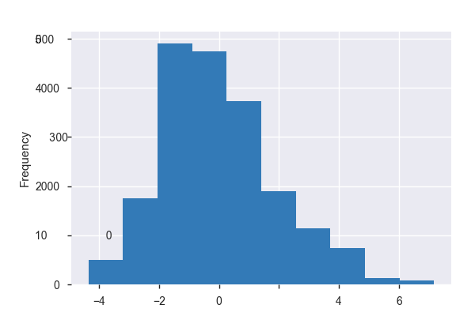

**Common Values**

| Value | Count | Frequency (%) |  |
| --- | --- | --- | --- |
| -1.3223521114630228 | 1 | 0.0% |  |
| -1.7672436596287566 | 1 | 0.0% |  |
| -2.201304833831817 | 1 | 0.0% |  |
| -1.2541260909398841 | 1 | 0.0% |  |
| 4.42980959047348 | 1 | 0.0% |  |
| -2.0444918177432463 | 1 | 0.0% |  |
| 4.028738823286202 | 1 | 0.0% |  |
| 3.967508468721951 | 1 | 0.0% |  |
| 0.1876634383014726 | 1 | 0.0% |  |
| -1.221127458680606 | 1 | 0.0% |  |
| Other values (19612) | 19612 | 99.9% |  |

**Extreme Values**

Minimum 5 values

| Value | Count | Frequency (%) |  |
| --- | --- | --- | --- |
| -4.353247873576144 | 1 | 0.0% |  |
| -4.286241489820225 | 1 | 0.0% |  |
| -4.260766222057143 | 1 | 0.0% |  |
| -4.257995777840921 | 1 | 0.0% |  |
| -4.226838921759658 | 1 | 0.0% |  |

Maximum 5 values

| Value | Count | Frequency (%) |  |
| --- | --- | --- | --- |
| 6.923170127155995 | 1 | 0.0% |  |
| 7.119151292663688 | 1 | 0.0% |  |
| 7.123378965211359 | 1 | 0.0% |  |
| 7.149361808881367 | 1 | 0.0% |  |
| 7.171497405774634 | 1 | 0.0% |  |

gyros_belt_z  
Numeric

| Distinct count | 19622 |
| --- | --- |
| Unique (%) | 100.0% |
| Missing (%) | 0.0% |
| Missing (n) | 0 |
| Infinite (%) | 0.0% |
| Infinite (n) | 0 |

| Mean | 4.0557e-17 |
| --- | --- |
| Minimum | -5.0266 |
| Maximum | 13.458 |
| Zeros (%) | 0.0% |

Toggle details

**Statistics**

Quantile statistics

| Minimum | -5.0266 |
| --- | --- |
| 5-th percentile | -3.0635 |
| Q1 | -1.1417 |
| Median | 0.22293 |
| Q3 | 1.2036 |
| 95-th percentile | 2.4616 |
| Maximum | 13.458 |
| Range | 18.485 |
| Interquartile range | 2.3453 |

Descriptive statistics

| Standard deviation | 1.6941 |
| --- | --- |
| Coef of variation | 4.1771e+16 |
| Kurtosis | -0.24853 |
| Mean | 4.0557e-17 |
| MAD | 1.3712 |
| Skewness | -0.39735 |
| Sum | 7.9581e-13 |
| Variance | 2.8699 |
| Memory size | 153.4 KiB |

**Histogram**

[figure not shown]

**Common Values**

| Value | Count | Frequency (%) |  |
| --- | --- | --- | --- |
| 0.37216644577403046 | 1 | 0.0% |  |
| 1.3509571149567747 | 1 | 0.0% |  |
| -2.344765440887797 | 1 | 0.0% |  |
| 1.0975448426609844 | 1 | 0.0% |  |
| -0.5041606623004672 | 1 | 0.0% |  |
| 0.5082234590678131 | 1 | 0.0% |  |
| -2.0825492178010556 | 1 | 0.0% |  |
| 0.3215643237988509 | 1 | 0.0% |  |
| -3.679158612784376 | 1 | 0.0% |  |
| -1.3006261426388965 | 1 | 0.0% |  |
| Other values (19612) | 19612 | 99.9% |  |

**Extreme Values**

Minimum 5 values

| Value | Count | Frequency (%) |  |
| --- | --- | --- | --- |
| -5.02661552677572 | 1 | 0.0% |  |
| -5.010631311606468 | 1 | 0.0% |  |
| -4.893273445734405 | 1 | 0.0% |  |
| -4.8613292821869925 | 1 | 0.0% |  |
| -4.859613586524067 | 1 | 0.0% |  |

Maximum 5 values

| Value | Count | Frequency (%) |  |
| --- | --- | --- | --- |
| 3.93888549288523 | 1 | 0.0% |  |
| 3.962233969302563 | 1 | 0.0% |  |
| 3.9814257713415344 | 1 | 0.0% |  |
| 4.039355956047999 | 1 | 0.0% |  |
| 13.45791873498572 | 1 | 0.0% |  |

gyros_dumbbell_x  
Numeric

| Distinct count | 19622 |
| --- | --- |
| Unique (%) | 100.0% |
| Missing (%) | 0.0% |
| Missing (n) | 0 |
| Infinite (%) | 0.0% |
| Infinite (n) | 0 |

| Mean | 7.2423e-18 |
| --- | --- |
| Minimum | -4.7079 |
| Maximum | 7.3012 |
| Zeros (%) | 0.0% |

Toggle details

**Statistics**

Quantile statistics

| Minimum | -4.7079 |
| --- | --- |
| 5-th percentile | -0.45035 |
| Q1 | -0.17352 |
| Median | -0.031165 |
| Q3 | 0.12494 |
| 95-th percentile | 0.50644 |
| Maximum | 7.3012 |
| Range | 12.009 |
| Interquartile range | 0.29846 |

Descriptive statistics

| Standard deviation | 0.42241 |
| --- | --- |
| Coef of variation | 5.8325e+16 |
| Kurtosis | 82.699 |
| Mean | 7.2423e-18 |
| MAD | 0.23096 |
| Skewness | 5.8873 |
| Sum | 1.4211e-13 |
| Variance | 0.17843 |
| Memory size | 153.4 KiB |

**Histogram**

[figure not shown]

**Common Values**

| Value | Count | Frequency (%) |  |
| --- | --- | --- | --- |
| 0.20422196738364573 | 1 | 0.0% |  |
| 0.13047970993610544 | 1 | 0.0% |  |
| -0.3735100478010218 | 1 | 0.0% |  |
| 0.13474829736265662 | 1 | 0.0% |  |
| 0.1347574305629934 | 1 | 0.0% |  |
| -0.21466432306391348 | 1 | 0.0% |  |
| 0.042212278835900556 | 1 | 0.0% |  |
| -0.12865454115848998 | 1 | 0.0% |  |
| 0.5063900905015759 | 1 | 0.0% |  |
| 0.12786879185311723 | 1 | 0.0% |  |
| Other values (19612) | 19612 | 99.9% |  |

**Extreme Values**

Minimum 5 values

| Value | Count | Frequency (%) |  |
| --- | --- | --- | --- |
| -4.70786795532203 | 1 | 0.0% |  |
| -2.765445383812692 | 1 | 0.0% |  |
| -2.6622170123661517 | 1 | 0.0% |  |
| -2.6367258361153945 | 1 | 0.0% |  |
| -2.514040997054233 | 1 | 0.0% |  |

Maximum 5 values

| Value | Count | Frequency (%) |  |
| --- | --- | --- | --- |
| 7.0460782043753145 | 1 | 0.0% |  |
| 7.053678575611822 | 1 | 0.0% |  |
| 7.117844398697432 | 1 | 0.0% |  |
| 7.262860462986515 | 1 | 0.0% |  |
| 7.301240081070094 | 1 | 0.0% |  |

gyros_dumbbell_y  
Numeric

| Distinct count | 19622 |
| --- | --- |
| Unique (%) | 100.0% |
| Missing (%) | 0.0% |
| Missing (n) | 0 |
| Infinite (%) | 0.0% |
| Infinite (n) | 0 |

| Mean | 1.2312e-17 |
| --- | --- |
| Minimum | -2.3451 |
| Maximum | 6.2195 |
| Zeros (%) | 0.0% |

Toggle details

**Statistics**

Quantile statistics

| Minimum | -2.3451 |
| --- | --- |
| 5-th percentile | -0.69249 |
| Q1 | -0.20611 |
| Median | -0.0053133 |
| Q3 | 0.20653 |
| 95-th percentile | 0.67926 |
| Maximum | 6.2195 |
| Range | 8.5647 |
| Interquartile range | 0.41265 |

Descriptive statistics

| Standard deviation | 0.41261 |
| --- | --- |
| Coef of variation | 3.3513e+16 |
| Kurtosis | 7.0197 |
| Mean | 1.2312e-17 |
| MAD | 0.29537 |
| Skewness | 0.40719 |
| Sum | 2.4158e-13 |
| Variance | 0.17025 |
| Memory size | 153.4 KiB |

**Histogram**

[figure not shown]

**Common Values**

| Value | Count | Frequency (%) |  |
| --- | --- | --- | --- |
| 0.06731559771876831 | 1 | 0.0% |  |
| 0.9704304243525129 | 1 | 0.0% |  |
| -0.22585499839805367 | 1 | 0.0% |  |
| 0.26731193231139233 | 1 | 0.0% |  |
| 0.897588874564188 | 1 | 0.0% |  |
| 0.35486825170246955 | 1 | 0.0% |  |
| 0.5344047989155473 | 1 | 0.0% |  |
| 0.3158249012865588 | 1 | 0.0% |  |
| 0.2708984963598174 | 1 | 0.0% |  |
| -0.3363148766204915 | 1 | 0.0% |  |
| Other values (19612) | 19612 | 99.9% |  |

**Extreme Values**

Minimum 5 values

| Value | Count | Frequency (%) |  |
| --- | --- | --- | --- |
| -2.34513887499923 | 1 | 0.0% |  |
| -2.1608278360821545 | 1 | 0.0% |  |
| -2.032674834428919 | 1 | 0.0% |  |
| -2.0323165747956105 | 1 | 0.0% |  |
| -2.014107836671913 | 1 | 0.0% |  |

Maximum 5 values

| Value | Count | Frequency (%) |  |
| --- | --- | --- | --- |
| 3.736767277645171 | 1 | 0.0% |  |
| 4.075347874128293 | 1 | 0.0% |  |
| 4.171204012624385 | 1 | 0.0% |  |
| 4.552978671396948 | 1 | 0.0% |  |
| 6.21952519596364 | 1 | 0.0% |  |

gyros_dumbbell_z  
Numeric

| Distinct count | 19622 |
| --- | --- |
| Unique (%) | 100.0% |
| Missing (%) | 0.0% |
| Missing (n) | 0 |
| Infinite (%) | 0.0% |
| Infinite (n) | 0 |

| Mean | 2.6072e-17 |
| --- | --- |
| Minimum | -1.8751 |
| Maximum | 2.7165 |
| Zeros (%) | 0.0% |

Toggle details

**Statistics**

Quantile statistics

| Minimum | -1.8751 |
| --- | --- |
| 5-th percentile | -0.58947 |
| Q1 | -0.18998 |
| Median | 0.015874 |
| Q3 | 0.18985 |
| 95-th percentile | 0.5637 |
| Maximum | 2.7165 |
| Range | 4.5917 |
| Interquartile range | 0.37984 |

Descriptive statistics

| Standard deviation | 0.35544 |
| --- | --- |
| Coef of variation | 1.3633e+16 |
| Kurtosis | 2.592 |
| Mean | 2.6072e-17 |
| MAD | 0.25986 |
| Skewness | 0.021385 |
| Sum | 5.1159e-13 |
| Variance | 0.12634 |
| Memory size | 153.4 KiB |

**Histogram**

[figure not shown]

**Common Values**

| Value | Count | Frequency (%) |  |
| --- | --- | --- | --- |
| 0.420218050844107 | 1 | 0.0% |  |
| -0.13516327235008072 | 1 | 0.0% |  |
| 0.47605086489612514 | 1 | 0.0% |  |
| -0.9327994093509425 | 1 | 0.0% |  |
| 0.26656608092057343 | 1 | 0.0% |  |
| -0.19240265487316807 | 1 | 0.0% |  |
| -0.6313670294291828 | 1 | 0.0% |  |
| -0.9237381226472571 | 1 | 0.0% |  |
| -0.6112572551793738 | 1 | 0.0% |  |
| -0.03726679740326468 | 1 | 0.0% |  |
| Other values (19612) | 19612 | 99.9% |  |

**Extreme Values**

Minimum 5 values

| Value | Count | Frequency (%) |  |
| --- | --- | --- | --- |
| -1.8751275929302755 | 1 | 0.0% |  |
| -1.8588821741371664 | 1 | 0.0% |  |
| -1.781189947250287 | 1 | 0.0% |  |
| -1.64565869875027 | 1 | 0.0% |  |
| -1.6446726405863827 | 1 | 0.0% |  |

Maximum 5 values

| Value | Count | Frequency (%) |  |
| --- | --- | --- | --- |
| 2.2208475446939615 | 1 | 0.0% |  |
| 2.4227382949707192 | 1 | 0.0% |  |
| 2.483742968107434 | 1 | 0.0% |  |
| 2.5608498611702197 | 1 | 0.0% |  |
| 2.7165491710165783 | 1 | 0.0% |  |

gyros_forearm_x  
Numeric

| Distinct count | 19622 |
| --- | --- |
| Unique (%) | 100.0% |
| Missing (%) | 0.0% |
| Missing (n) | 0 |
| Infinite (%) | 0.0% |
| Infinite (n) | 0 |

| Mean | 7.2423e-18 |
| --- | --- |
| Minimum | -0.91084 |
| Maximum | 1.8762 |
| Zeros (%) | 0.0% |

Toggle details

**Statistics**

Quantile statistics

| Minimum | -0.91084 |
| --- | --- |
| 5-th percentile | -0.27555 |
| Q1 | -0.11342 |
| Median | -0.013295 |
| Q3 | 0.098866 |
| 95-th percentile | 0.31062 |
| Maximum | 1.8762 |
| Range | 2.7871 |
| Interquartile range | 0.21228 |

Descriptive statistics

| Standard deviation | 0.18415 |
| --- | --- |
| Coef of variation | 2.5427e+16 |
| Kurtosis | 2.967 |
| Mean | 7.2423e-18 |
| MAD | 0.13793 |
| Skewness | 0.67515 |
| Sum | 1.4211e-13 |
| Variance | 0.033912 |
| Memory size | 153.4 KiB |

**Histogram**

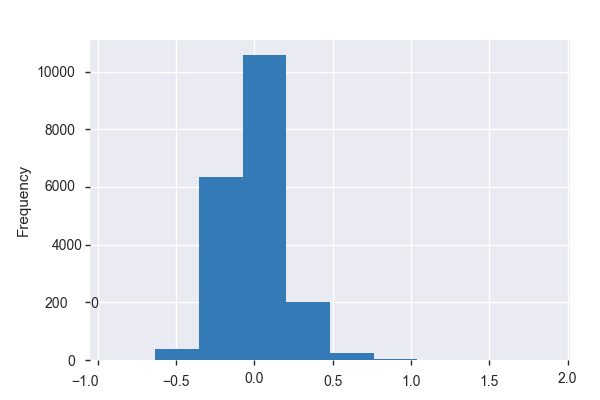

**Common Values**

| Value | Count | Frequency (%) |  |
| --- | --- | --- | --- |
| 0.105587601321124 | 1 | 0.0% |  |
| -0.16172971367414185 | 1 | 0.0% |  |
| 0.1331330286653819 | 1 | 0.0% |  |
| -0.02575705373893109 | 1 | 0.0% |  |
| -0.10584801112218907 | 1 | 0.0% |  |
| 0.3262487202838945 | 1 | 0.0% |  |
| -0.02915512673842929 | 1 | 0.0% |  |
| -0.0518497007112533 | 1 | 0.0% |  |
| -0.0014797363862346776 | 1 | 0.0% |  |
| 0.005592568611882751 | 1 | 0.0% |  |
| Other values (19612) | 19612 | 99.9% |  |

**Extreme Values**

Minimum 5 values

| Value | Count | Frequency (%) |  |
| --- | --- | --- | --- |
| -0.9108410939562323 | 1 | 0.0% |  |
| -0.8373751566303692 | 1 | 0.0% |  |
| -0.8245331302198982 | 1 | 0.0% |  |
| -0.8090513301435326 | 1 | 0.0% |  |
| -0.7273924557896468 | 1 | 0.0% |  |

Maximum 5 values

| Value | Count | Frequency (%) |  |
| --- | --- | --- | --- |
| 1.2829748235174925 | 1 | 0.0% |  |
| 1.37082960745982 | 1 | 0.0% |  |
| 1.4033120443218217 | 1 | 0.0% |  |
| 1.5252811151584926 | 1 | 0.0% |  |
| 1.8762249985838542 | 1 | 0.0% |  |

gyros_forearm_y  
Numeric

| Distinct count | 19622 |
| --- | --- |
| Unique (%) | 100.0% |
| Missing (%) | 0.0% |
| Missing (n) | 0 |
| Infinite (%) | 0.0% |
| Infinite (n) | 0 |

| Mean | -1.3036e-17 |
| --- | --- |
| Minimum | -1.3494 |
| Maximum | 6.3139 |
| Zeros (%) | 0.0% |

Toggle details

**Statistics**

Quantile statistics

| Minimum | -1.3494 |
| --- | --- |
| 5-th percentile | -0.27929 |
| Q1 | -0.099725 |
| Median | 0.0050291 |
| Q3 | 0.10254 |
| 95-th percentile | 0.27164 |
| Maximum | 6.3139 |
| Range | 7.6632 |
| Interquartile range | 0.20227 |

Descriptive statistics

| Standard deviation | 0.17584 |
| --- | --- |
| Coef of variation | -1.3488e+16 |
| Kurtosis | 86.042 |
| Mean | -1.3036e-17 |
| MAD | 0.12874 |
| Skewness | 2.0367 |
| Sum | -2.558e-13 |
| Variance | 0.030919 |
| Memory size | 153.4 KiB |

**Histogram**

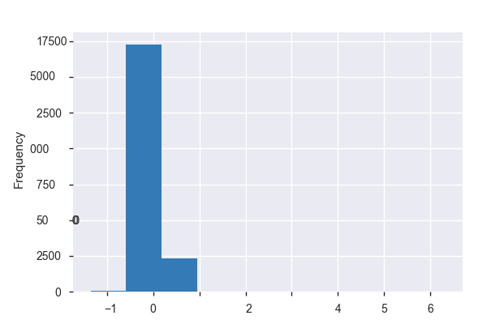

**Common Values**

| Value | Count | Frequency (%) |  |
| --- | --- | --- | --- |
| 0.024913868269460637 | 1 | 0.0% |  |
| -0.5148963609806043 | 1 | 0.0% |  |
| -0.04156740851763313 | 1 | 0.0% |  |
| 0.1767617011917225 | 1 | 0.0% |  |
| 0.12448605881964883 | 1 | 0.0% |  |
| 0.06932993233080911 | 1 | 0.0% |  |
| 0.40522722745477885 | 1 | 0.0% |  |
| -0.17430824536414313 | 1 | 0.0% |  |
| -0.06861496939240629 | 1 | 0.0% |  |
| 0.25311336910851556 | 1 | 0.0% |  |
| Other values (19612) | 19612 | 99.9% |  |

**Extreme Values**

Minimum 5 values

| Value | Count | Frequency (%) |  |
| --- | --- | --- | --- |
| -1.3493604644963613 | 1 | 0.0% |  |
| -1.3491412835518348 | 1 | 0.0% |  |
| -1.301819257527598 | 1 | 0.0% |  |
| -1.0573626886326752 | 1 | 0.0% |  |
| -0.9715199235802406 | 1 | 0.0% |  |

Maximum 5 values

| Value | Count | Frequency (%) |  |
| --- | --- | --- | --- |
| 0.6604671431648037 | 1 | 0.0% |  |
| 0.7130222333559939 | 1 | 0.0% |  |
| 0.7182817384623342 | 1 | 0.0% |  |
| 0.9568195007827651 | 1 | 0.0% |  |
| 6.3138709551436145 | 1 | 0.0% |  |

gyros_forearm_z  
Numeric

| Distinct count | 19622 |
| --- | --- |
| Unique (%) | 100.0% |
| Missing (%) | 0.0% |
| Missing (n) | 0 |
| Infinite (%) | 0.0% |
| Infinite (n) | 0 |

| Mean | 5.7938e-18 |
| --- | --- |
| Minimum | -1.6588 |
| Maximum | 2.9061 |
| Zeros (%) | 0.0% |

Toggle details

**Statistics**

Quantile statistics

| Minimum | -1.6588 |
| --- | --- |
| 5-th percentile | -0.24371 |
| Q1 | -0.07568 |
| Median | 0.0093479 |
| Q3 | 0.086649 |
| 95-th percentile | 0.22289 |
| Maximum | 2.9061 |
| Range | 4.5649 |
| Interquartile range | 0.16233 |

Descriptive statistics

| Standard deviation | 0.16793 |
| --- | --- |
| Coef of variation | 2.8983e+16 |
| Kurtosis | 20.106 |
| Mean | 5.7938e-18 |
| MAD | 0.11265 |
| Skewness | -1.0634 |
| Sum | 1.1369e-13 |
| Variance | 0.028199 |
| Memory size | 153.4 KiB |

**Histogram**

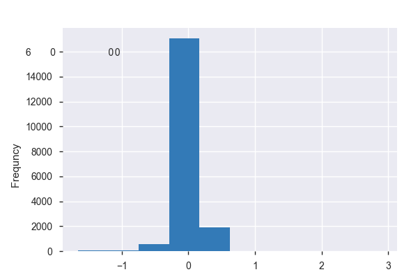

**Common Values**

| Value | Count | Frequency (%) |  |
| --- | --- | --- | --- |
| 0.08969870255250037 | 1 | 0.0% |  |
| 0.141191346836341 | 1 | 0.0% |  |
| -0.05762609480588679 | 1 | 0.0% |  |
| -0.0885037983301465 | 1 | 0.0% |  |
| 0.13803535604977715 | 1 | 0.0% |  |
| 0.0234303661078364 | 1 | 0.0% |  |
| -0.19349749233328434 | 1 | 0.0% |  |
| -0.05170538202643743 | 1 | 0.0% |  |
| -0.052588090323647106 | 1 | 0.0% |  |
| -0.17777470547282903 | 1 | 0.0% |  |
| Other values (19612) | 19612 | 99.9% |  |

**Extreme Values**

Minimum 5 values

| Value | Count | Frequency (%) |  |
| --- | --- | --- | --- |
| -1.6587841631631388 | 1 | 0.0% |  |
| -1.6372020615102072 | 1 | 0.0% |  |
| -1.5905377839187425 | 1 | 0.0% |  |
| -1.5557090638563424 | 1 | 0.0% |  |
| -1.551496470537038 | 1 | 0.0% |  |

Maximum 5 values

| Value | Count | Frequency (%) |  |
| --- | --- | --- | --- |
| 1.3560865265155309 | 1 | 0.0% |  |
| 1.422031121940474 | 1 | 0.0% |  |
| 1.998706800652848 | 1 | 0.0% |  |
| 2.2100025816979825 | 1 | 0.0% |  |
| 2.906108891518882 | 1 | 0.0% |  |

magnet_arm_x  
Numeric

| Distinct count | 19622 |
| --- | --- |
| Unique (%) | 100.0% |
| Missing (%) | 0.0% |
| Missing (n) | 0 |
| Infinite (%) | 0.0% |
| Infinite (n) | 0 |

| Mean | -1.6657e-17 |
| --- | --- |
| Minimum | -3.6679 |
| Maximum | 11.658 |
| Zeros (%) | 0.0% |

Toggle details

**Statistics**

Quantile statistics

| Minimum | -3.6679 |
| --- | --- |
| 5-th percentile | -1.0153 |
| Q1 | -0.37315 |
| Median | -0.0019333 |
| Q3 | 0.38501 |
| 95-th percentile | 0.99825 |
| Maximum | 11.658 |
| Range | 15.326 |
| Interquartile range | 0.75816 |

Descriptive statistics

| Standard deviation | 0.61614 |
| --- | --- |
| Coef of variation | -3.6989e+16 |
| Kurtosis | 7.3748 |
| Mean | -1.6657e-17 |
| MAD | 0.47021 |
| Skewness | 0.16944 |
| Sum | -3.2685e-13 |
| Variance | 0.37963 |
| Memory size | 153.4 KiB |

**Histogram**

[figure not shown]

**Common Values**

| Value | Count | Frequency (%) |  |
| --- | --- | --- | --- |
| 0.5392564654646096 | 1 | 0.0% |  |
| -0.278515761074951 | 1 | 0.0% |  |
| -0.2077060534526962 | 1 | 0.0% |  |
| 0.8683072923644892 | 1 | 0.0% |  |
| 1.1246085906271786 | 1 | 0.0% |  |
| 0.5594541078240696 | 1 | 0.0% |  |
| -0.21118146477021107 | 1 | 0.0% |  |
| 0.17878575192578855 | 1 | 0.0% |  |
| -0.6206695266627457 | 1 | 0.0% |  |
| -1.8171245931651654 | 1 | 0.0% |  |
| Other values (19612) | 19612 | 99.9% |  |

**Extreme Values**

Minimum 5 values

| Value | Count | Frequency (%) |  |
| --- | --- | --- | --- |
| -3.6678780474007664 | 1 | 0.0% |  |
| -3.491707090368549 | 1 | 0.0% |  |
| -3.263949000623982 | 1 | 0.0% |  |
| -3.220387910185247 | 1 | 0.0% |  |
| -3.003101300085634 | 1 | 0.0% |  |

Maximum 5 values

| Value | Count | Frequency (%) |  |
| --- | --- | --- | --- |
| 2.273387935609643 | 1 | 0.0% |  |
| 2.287546990190773 | 1 | 0.0% |  |
| 2.475891442085984 | 1 | 0.0% |  |
| 2.715360037394808 | 1 | 0.0% |  |
| 11.658359061442138 | 1 | 0.0% |  |

magnet_arm_y  
Numeric

| Distinct count | 19622 |
| --- | --- |
| Unique (%) | 100.0% |
| Missing (%) | 0.0% |
| Missing (n) | 0 |
| Infinite (%) | 0.0% |
| Infinite (n) | 0 |

| Mean | 1.0139e-17 |
| --- | --- |
| Minimum | -3.742 |
| Maximum | 4.2286 |
| Zeros (%) | 0.0% |

Toggle details

**Statistics**

Quantile statistics

| Minimum | -3.742 |
| --- | --- |
| 5-th percentile | -0.9457 |
| Q1 | -0.34102 |
| Median | 0.003527 |
| Q3 | 0.34201 |
| 95-th percentile | 0.92144 |
| Maximum | 4.2286 |
| Range | 7.9706 |
| Interquartile range | 0.68303 |

Descriptive statistics

| Standard deviation | 0.57789 |
| --- | --- |
| Coef of variation | 5.6995e+16 |
| Kurtosis | 1.8123 |
| Mean | 1.0139e-17 |
| MAD | 0.43911 |
| Skewness | -0.0074488 |
| Sum | 1.9895e-13 |
| Variance | 0.33396 |
| Memory size | 153.4 KiB |

**Histogram**

[figure not shown]

**Common Values**

| Value | Count | Frequency (%) |  |
| --- | --- | --- | --- |
| 0.12097885062576075 | 1 | 0.0% |  |
| -0.1188075109247101 | 1 | 0.0% |  |
| -0.12865471699309117 | 1 | 0.0% |  |
| -0.07450440104578326 | 1 | 0.0% |  |
| 0.27803631028927345 | 1 | 0.0% |  |
| -0.06775192797295292 | 1 | 0.0% |  |
| -0.21071551662520374 | 1 | 0.0% |  |
| 0.06710505125399012 | 1 | 0.0% |  |
| 0.8837877026462918 | 1 | 0.0% |  |
| -0.7357157638903011 | 1 | 0.0% |  |
| Other values (19612) | 19612 | 99.9% |  |

**Extreme Values**

Minimum 5 values

| Value | Count | Frequency (%) |  |
| --- | --- | --- | --- |
| -3.741990060610919 | 1 | 0.0% |  |
| -3.5755358766769034 | 1 | 0.0% |  |
| -3.525241801812757 | 1 | 0.0% |  |
| -3.4128767756361373 | 1 | 0.0% |  |
| -3.356188525348891 | 1 | 0.0% |  |

Maximum 5 values

| Value | Count | Frequency (%) |  |
| --- | --- | --- | --- |
| 2.8452526204692252 | 1 | 0.0% |  |
| 2.8548100408504054 | 1 | 0.0% |  |
| 2.877267969661555 | 1 | 0.0% |  |
| 3.035045651417658 | 1 | 0.0% |  |
| 4.228568779745731 | 1 | 0.0% |  |

magnet_arm_z  
Numeric

| Distinct count | 19622 |
| --- | --- |
| Unique (%) | 100.0% |
| Missing (%) | 0.0% |
| Missing (n) | 0 |
| Infinite (%) | 0.0% |
| Infinite (n) | 0 |

| Mean | 2.8969e-18 |
| --- | --- |
| Minimum | -2.2766 |
| Maximum | 8.71 |
| Zeros (%) | 0.0% |

Toggle details

**Statistics**

Quantile statistics

| Minimum | -2.2766 |
| --- | --- |
| 5-th percentile | -0.70083 |
| Q1 | -0.26263 |
| Median | -0.0094639 |
| Q3 | 0.2287 |
| 95-th percentile | 0.6673 |
| Maximum | 8.71 |
| Range | 10.987 |
| Interquartile range | 0.49132 |

Descriptive statistics

| Standard deviation | 0.54483 |
| --- | --- |
| Coef of variation | 1.8807e+17 |
| Kurtosis | 52.496 |
| Mean | 2.8969e-18 |
| MAD | 0.33574 |
| Skewness | 4.2989 |
| Sum | 5.6843e-14 |
| Variance | 0.29684 |
| Memory size | 153.4 KiB |

**Histogram**

[figure not shown]

**Common Values**

| Value | Count | Frequency (%) |  |
| --- | --- | --- | --- |
| -0.64423629913718 | 1 | 0.0% |  |
| -0.3107593100766006 | 1 | 0.0% |  |
| 0.2657509224806538 | 1 | 0.0% |  |
| 0.0626213746476824 | 1 | 0.0% |  |
| -0.2222550097073055 | 1 | 0.0% |  |
| -0.12310023927157027 | 1 | 0.0% |  |
| -0.23129961996761328 | 1 | 0.0% |  |
| 0.13305351983934963 | 1 | 0.0% |  |
| 0.10062168622498091 | 1 | 0.0% |  |
| -0.06764726473180768 | 1 | 0.0% |  |
| Other values (19612) | 19612 | 99.9% |  |

**Extreme Values**

Minimum 5 values

| Value | Count | Frequency (%) |  |
| --- | --- | --- | --- |
| -2.276646698815233 | 1 | 0.0% |  |
| -2.0919491379878594 | 1 | 0.0% |  |
| -2.0863669890916294 | 1 | 0.0% |  |
| -2.0814173641389613 | 1 | 0.0% |  |
| -2.076275396237956 | 1 | 0.0% |  |

Maximum 5 values

| Value | Count | Frequency (%) |  |
| --- | --- | --- | --- |
| 8.122092749639902 | 1 | 0.0% |  |
| 8.163650834870186 | 1 | 0.0% |  |
| 8.292444656984058 | 1 | 0.0% |  |
| 8.449252803345924 | 1 | 0.0% |  |
| 8.71000081980906 | 1 | 0.0% |  |

magnet_belt_x  
Numeric

| Distinct count | 19622 |
| --- | --- |
| Unique (%) | 100.0% |
| Missing (%) | 0.0% |
| Missing (n) | 0 |
| Infinite (%) | 0.0% |
| Infinite (n) | 0 |

| Mean | 2.6072e-17 |
| --- | --- |
| Minimum | -3.5619 |
| Maximum | 8.7529 |
| Zeros (%) | 0.0% |

Toggle details

**Statistics**

Quantile statistics

| Minimum | -3.5619 |
| --- | --- |
| 5-th percentile | -1.9364 |
| Q1 | -0.73193 |
| Median | -0.0907 |
| Q3 | 0.77891 |
| 95-th percentile | 1.9946 |
| Maximum | 8.7529 |
| Range | 12.315 |
| Interquartile range | 1.5108 |

Descriptive statistics

| Standard deviation | 1.1955 |
| --- | --- |
| Coef of variation | 4.5854e+16 |
| Kurtosis | 0.27171 |
| Mean | 2.6072e-17 |
| MAD | 0.94138 |
| Skewness | 0.098922 |
| Sum | 5.1159e-13 |
| Variance | 1.4292 |
| Memory size | 153.4 KiB |

**Histogram**

[figure not shown]

**Common Values**

| Value | Count | Frequency (%) |  |
| --- | --- | --- | --- |
| -0.006553049435928563 | 1 | 0.0% |  |
| 0.689989000637385 | 1 | 0.0% |  |
| -1.3308333205872607 | 1 | 0.0% |  |
| 0.9684493008545674 | 1 | 0.0% |  |
| 2.210169744841753 | 1 | 0.0% |  |
| 0.02099512181741812 | 1 | 0.0% |  |
| 0.04883262527684958 | 1 | 0.0% |  |
| 1.0353796163292637 | 1 | 0.0% |  |
| -0.4561581179781669 | 1 | 0.0% |  |
| 0.1287960223001267 | 1 | 0.0% |  |
| Other values (19612) | 19612 | 99.9% |  |

**Extreme Values**

Minimum 5 values

| Value | Count | Frequency (%) |  |
| --- | --- | --- | --- |
| -3.561922508998969 | 1 | 0.0% |  |
| -3.553026621814031 | 1 | 0.0% |  |
| -3.5398347514335557 | 1 | 0.0% |  |
| -3.4219415817914283 | 1 | 0.0% |  |
| -3.4153096111592225 | 1 | 0.0% |  |

Maximum 5 values

| Value | Count | Frequency (%) |  |
| --- | --- | --- | --- |
| 4.336075284397133 | 1 | 0.0% |  |
| 4.433933978436902 | 1 | 0.0% |  |
| 4.574770593232647 | 1 | 0.0% |  |
| 4.707313586215523 | 1 | 0.0% |  |
| 8.752868393838426 | 1 | 0.0% |  |

magnet_belt_y  
Numeric

| Distinct count | 19622 |
| --- | --- |
| Unique (%) | 100.0% |
| Missing (%) | 0.0% |
| Missing (n) | 0 |
| Infinite (%) | 0.0% |
| Infinite (n) | 0 |

| Mean | -1.1588e-17 |
| --- | --- |
| Minimum | -4.9588 |
| Maximum | 10.706 |
| Zeros (%) | 0.0% |

Toggle details

**Statistics**

Quantile statistics

| Minimum | -4.9588 |
| --- | --- |
| 5-th percentile | -1.7792 |
| Q1 | -0.5831 |
| Median | 0.044323 |
| Q3 | 0.64911 |
| 95-th percentile | 1.5936 |
| Maximum | 10.706 |
| Range | 15.665 |
| Interquartile range | 1.2322 |

Descriptive statistics

| Standard deviation | 1.0469 |
| --- | --- |
| Coef of variation | -9.0348e+16 |
| Kurtosis | 2.0204 |
| Mean | -1.1588e-17 |
| MAD | 0.79614 |
| Skewness | -0.39388 |
| Sum | -2.2737e-13 |
| Variance | 1.096 |
| Memory size | 153.4 KiB |

**Histogram**

[figure not shown]

**Common Values**

| Value | Count | Frequency (%) |  |
| --- | --- | --- | --- |
| -1.3572168246098737 | 1 | 0.0% |  |
| -2.7305956684320782 | 1 | 0.0% |  |
| -0.7089178717348373 | 1 | 0.0% |  |
| -0.7449953578660827 | 1 | 0.0% |  |
| -1.1704032167271017 | 1 | 0.0% |  |
| -1.5476840142376267 | 1 | 0.0% |  |
| 0.45192379957638873 | 1 | 0.0% |  |
| 0.01700710794866445 | 1 | 0.0% |  |
| 1.553007075453388 | 1 | 0.0% |  |
| 0.42062906809464246 | 1 | 0.0% |  |
| Other values (19612) | 19612 | 99.9% |  |

**Extreme Values**

Minimum 5 values

| Value | Count | Frequency (%) |  |
| --- | --- | --- | --- |
| -4.958790273051326 | 1 | 0.0% |  |
| -4.728539279160995 | 1 | 0.0% |  |
| -4.664487028615846 | 1 | 0.0% |  |
| -4.621474687269233 | 1 | 0.0% |  |
| -4.586084328157815 | 1 | 0.0% |  |

Maximum 5 values

| Value | Count | Frequency (%) |  |
| --- | --- | --- | --- |
| 3.8996047039568875 | 1 | 0.0% |  |
| 3.92618807893891 | 1 | 0.0% |  |
| 4.02215541070147 | 1 | 0.0% |  |
| 4.084919543084157 | 1 | 0.0% |  |
| 10.706230276382263 | 1 | 0.0% |  |

magnet_belt_z  
Numeric

| Distinct count | 19622 |
| --- | --- |
| Unique (%) | 100.0% |
| Missing (%) | 0.0% |
| Missing (n) | 0 |
| Infinite (%) | 0.0% |
| Infinite (n) | 0 |

| Mean | -1.1588e-17 |
| --- | --- |
| Minimum | -6.1196 |
| Maximum | 7.239 |
| Zeros (%) | 0.0% |

Toggle details

**Statistics**

Quantile statistics

| Minimum | -6.1196 |
| --- | --- |
| 5-th percentile | -1.6315 |
| Q1 | -0.46532 |
| Median | 0.089703 |
| Q3 | 0.5392 |
| 95-th percentile | 1.3411 |
| Maximum | 7.239 |
| Range | 13.359 |
| Interquartile range | 1.0045 |

Descriptive statistics

| Standard deviation | 1.0015 |
| --- | --- |
| Coef of variation | -8.6427e+16 |
| Kurtosis | 5.4872 |
| Mean | -1.1588e-17 |
| MAD | 0.69957 |
| Skewness | -0.37075 |
| Sum | -2.2737e-13 |
| Variance | 1.003 |
| Memory size | 153.4 KiB |

**Histogram**

[figure not shown]

**Common Values**

| Value | Count | Frequency (%) |  |
| --- | --- | --- | --- |
| 0.7144823801082076 | 1 | 0.0% |  |
| 1.8915302984593891 | 1 | 0.0% |  |
| -1.1698625701274867 | 1 | 0.0% |  |
| 1.4871338110560357 | 1 | 0.0% |  |
| 0.2944729301905118 | 1 | 0.0% |  |
| -2.2292253299811153 | 1 | 0.0% |  |
| -1.5226238336339606 | 1 | 0.0% |  |
| -0.42024406340454157 | 1 | 0.0% |  |
| 0.3206306504928315 | 1 | 0.0% |  |
| -1.5659451297176252 | 1 | 0.0% |  |
| Other values (19612) | 19612 | 99.9% |  |

**Extreme Values**

Minimum 5 values

| Value | Count | Frequency (%) |  |
| --- | --- | --- | --- |
| -6.119585411338393 | 1 | 0.0% |  |
| -6.103386550296443 | 1 | 0.0% |  |
| -6.021028621815702 | 1 | 0.0% |  |
| -5.9595575735648945 | 1 | 0.0% |  |
| -5.853772498578524 | 1 | 0.0% |  |

Maximum 5 values

| Value | Count | Frequency (%) |  |
| --- | --- | --- | --- |
| 6.848021421321217 | 1 | 0.0% |  |
| 6.952109281900094 | 1 | 0.0% |  |
| 7.091037135659183 | 1 | 0.0% |  |
| 7.16174702406472 | 1 | 0.0% |  |
| 7.2389702855580165 | 1 | 0.0% |  |

magnet_dumbbell_x  
Numeric

| Distinct count | 19622 |
| --- | --- |
| Unique (%) | 100.0% |
| Missing (%) | 0.0% |
| Missing (n) | 0 |
| Infinite (%) | 0.0% |
| Infinite (n) | 0 |

| Mean | 3.6936e-17 |
| --- | --- |
| Minimum | -1.2417 |
| Maximum | 1.4627 |
| Zeros (%) | 0.0% |

Toggle details

**Statistics**

Quantile statistics

| Minimum | -1.2417 |
| --- | --- |
| 5-th percentile | -0.45114 |
| Q1 | -0.16803 |
| Median | 0.0069222 |
| Q3 | 0.17361 |
| 95-th percentile | 0.42546 |
| Maximum | 1.4627 |
| Range | 2.7043 |
| Interquartile range | 0.34164 |

Descriptive statistics

| Standard deviation | 0.27141 |
| --- | --- |
| Coef of variation | 7348100000000000 |
| Kurtosis | 0.82212 |
| Mean | 3.6936e-17 |
| MAD | 0.21041 |
| Skewness | -0.15061 |
| Sum | 7.2475e-13 |
| Variance | 0.073663 |
| Memory size | 153.4 KiB |

**Histogram**

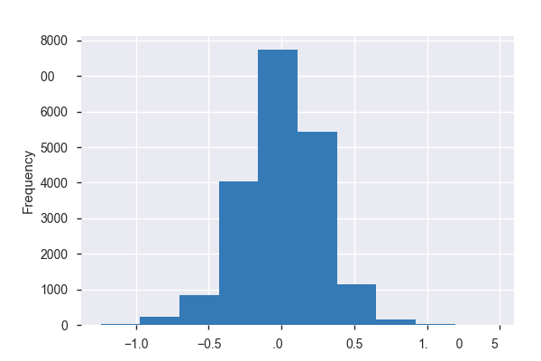

**Common Values**

| Value | Count | Frequency (%) |  |
| --- | --- | --- | --- |
| 0.02704194088843042 | 1 | 0.0% |  |
| 0.056170677914500436 | 1 | 0.0% |  |
| -0.02670114024753319 | 1 | 0.0% |  |
| -0.2452469810059524 | 1 | 0.0% |  |
| -0.065457109423144 | 1 | 0.0% |  |
| 0.22919570594313451 | 1 | 0.0% |  |
| -0.20702346318988 | 1 | 0.0% |  |
| 0.1363696610961891 | 1 | 0.0% |  |
| 0.03367768648729031 | 1 | 0.0% |  |
| 0.03928280241752366 | 1 | 0.0% |  |
| Other values (19612) | 19612 | 99.9% |  |

**Extreme Values**

Minimum 5 values

| Value | Count | Frequency (%) |  |
| --- | --- | --- | --- |
| -1.2416592268843398 | 1 | 0.0% |  |
| -1.2367228915172377 | 1 | 0.0% |  |
| -1.2044329856769018 | 1 | 0.0% |  |
| -1.200835336107945 | 1 | 0.0% |  |
| -1.136924023333932 | 1 | 0.0% |  |

Maximum 5 values

| Value | Count | Frequency (%) |  |
| --- | --- | --- | --- |
| 1.0556181285253983 | 1 | 0.0% |  |
| 1.1006492002374457 | 1 | 0.0% |  |
| 1.179386756406382 | 1 | 0.0% |  |
| 1.2833591462294769 | 1 | 0.0% |  |
| 1.4626837728934659 | 1 | 0.0% |  |

magnet_dumbbell_y  
Numeric

| Distinct count | 19622 |
| --- | --- |
| Unique (%) | 100.0% |
| Missing (%) | 0.0% |
| Missing (n) | 0 |
| Infinite (%) | 0.0% |
| Infinite (n) | 0 |

| Mean | -3.6212e-17 |
| --- | --- |
| Minimum | -1.0806 |
| Maximum | 1.7565 |
| Zeros (%) | 0.0% |

Toggle details

**Statistics**

Quantile statistics

| Minimum | -1.0806 |
| --- | --- |
| 5-th percentile | -0.40172 |
| Q1 | -0.13909 |
| Median | -0.0024735 |
| Q3 | 0.13623 |
| 95-th percentile | 0.3893 |
| Maximum | 1.7565 |
| Range | 2.8371 |
| Interquartile range | 0.27532 |

Descriptive statistics

| Standard deviation | 0.2563 |
| --- | --- |
| Coef of variation | -7078000000000000 |
| Kurtosis | 2.7087 |
| Mean | -3.6212e-17 |
| MAD | 0.1858 |
| Skewness | 0.31759 |
| Sum | -7.1054e-13 |
| Variance | 0.065692 |
| Memory size | 153.4 KiB |

**Histogram**

[figure not shown]

**Common Values**

| Value | Count | Frequency (%) |  |
| --- | --- | --- | --- |
| -0.0203670751661797 | 1 | 0.0% |  |
| -0.055293200064579995 | 1 | 0.0% |  |
| 0.19002173180996706 | 1 | 0.0% |  |
| -0.07440082222592351 | 1 | 0.0% |  |
| 0.0046466868947742995 | 1 | 0.0% |  |
| 0.00035810232306678644 | 1 | 0.0% |  |
| 0.14773959656274374 | 1 | 0.0% |  |
| -0.0011111237117166755 | 1 | 0.0% |  |
| -0.2285742594904319 | 1 | 0.0% |  |
| -0.05299073602071227 | 1 | 0.0% |  |
| Other values (19612) | 19612 | 99.9% |  |

**Extreme Values**

Minimum 5 values

| Value | Count | Frequency (%) |  |
| --- | --- | --- | --- |
| -1.08060586670782 | 1 | 0.0% |  |
| -1.0390097156509195 | 1 | 0.0% |  |
| -0.9825837961003182 | 1 | 0.0% |  |
| -0.9801133497758489 | 1 | 0.0% |  |
| -0.9650385582555773 | 1 | 0.0% |  |

Maximum 5 values

| Value | Count | Frequency (%) |  |
| --- | --- | --- | --- |
| 1.1867647624915882 | 1 | 0.0% |  |
| 1.2065790913739556 | 1 | 0.0% |  |
| 1.207721656647044 | 1 | 0.0% |  |
| 1.5968939508296576 | 1 | 0.0% |  |
| 1.7564969213336286 | 1 | 0.0% |  |

magnet_dumbbell_z  
Numeric

| Distinct count | 19622 |
| --- | --- |
| Unique (%) | 100.0% |
| Missing (%) | 0.0% |
| Missing (n) | 0 |
| Infinite (%) | 0.0% |
| Infinite (n) | 0 |

| Mean | 3.6936e-17 |
| --- | --- |
| Minimum | -1.2074 |
| Maximum | 1.3875 |
| Zeros (%) | 0.0% |

Toggle details

**Statistics**

Quantile statistics

| Minimum | -1.2074 |
| --- | --- |
| 5-th percentile | -0.35873 |
| Q1 | -0.13323 |
| Median | -0.0091887 |
| Q3 | 0.1109 |
| 95-th percentile | 0.40621 |
| Maximum | 1.3875 |
| Range | 2.595 |
| Interquartile range | 0.24413 |

Descriptive statistics

| Standard deviation | 0.23663 |
| --- | --- |
| Coef of variation | 6406600000000000 |
| Kurtosis | 2.3372 |
| Mean | 3.6936e-17 |
| MAD | 0.17009 |
| Skewness | 0.5752 |
| Sum | 7.2475e-13 |
| Variance | 0.055994 |
| Memory size | 153.4 KiB |

**Histogram**

[figure not shown]

**Common Values**

| Value | Count | Frequency (%) |  |
| --- | --- | --- | --- |
| 0.3468262022055172 | 1 | 0.0% |  |
| -0.49892943718290855 | 1 | 0.0% |  |
| -0.7674978776830719 | 1 | 0.0% |  |
| -0.07186157515411822 | 1 | 0.0% |  |
| 0.0032162615086173984 | 1 | 0.0% |  |
| 0.05516343946574837 | 1 | 0.0% |  |
| 0.26492385557027354 | 1 | 0.0% |  |
| 0.2610003608843785 | 1 | 0.0% |  |
| -0.31310457600281716 | 1 | 0.0% |  |
| -0.08213494038330406 | 1 | 0.0% |  |
| Other values (19612) | 19612 | 99.9% |  |

**Extreme Values**

Minimum 5 values

| Value | Count | Frequency (%) |  |
| --- | --- | --- | --- |
| -1.207441855395337 | 1 | 0.0% |  |
| -1.1713906711152562 | 1 | 0.0% |  |
| -1.108821768129599 | 1 | 0.0% |  |
| -1.1054332867550525 | 1 | 0.0% |  |
| -1.078104703042361 | 1 | 0.0% |  |

Maximum 5 values

| Value | Count | Frequency (%) |  |
| --- | --- | --- | --- |
| 1.1909527910502515 | 1 | 0.0% |  |
| 1.2060803167707281 | 1 | 0.0% |  |
| 1.2693672315639322 | 1 | 0.0% |  |
| 1.3234755849236812 | 1 | 0.0% |  |
| 1.387517475195219 | 1 | 0.0% |  |

magnet_forearm_x  
Numeric

| Distinct count | 19622 |
| --- | --- |
| Unique (%) | 100.0% |
| Missing (%) | 0.0% |
| Missing (n) | 0 |
| Infinite (%) | 0.0% |
| Infinite (n) | 0 |

| Mean | 2.7159e-19 |
| --- | --- |
| Minimum | -0.80629 |
| Maximum | 0.97845 |
| Zeros (%) | 0.0% |

Toggle details

**Statistics**

Quantile statistics

| Minimum | -0.80629 |
| --- | --- |
| 5-th percentile | -0.16747 |
| Q1 | -0.056758 |
| Median | -0.00063447 |
| Q3 | 0.05465 |
| 95-th percentile | 0.17649 |
| Maximum | 0.97845 |
| Range | 1.7847 |
| Interquartile range | 0.11141 |

Descriptive statistics

| Standard deviation | 0.11451 |
| --- | --- |
| Coef of variation | 4.2165e+17 |
| Kurtosis | 5.2176 |
| Mean | 2.7159e-19 |
| MAD | 0.079091 |
| Skewness | -0.013005 |
| Sum | 5.3291e-15 |
| Variance | 0.013113 |
| Memory size | 153.4 KiB |

**Histogram**

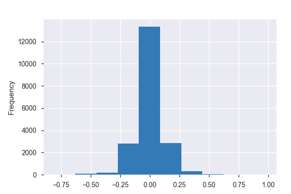

**Common Values**

| Value | Count | Frequency (%) |  |
| --- | --- | --- | --- |
| -0.06229838809623544 | 1 | 0.0% |  |
| 0.029194478463843286 | 1 | 0.0% |  |
| 0.011933888197528436 | 1 | 0.0% |  |
| -0.008456879247615073 | 1 | 0.0% |  |
| 0.09274819905410511 | 1 | 0.0% |  |
| -0.168317597091893 | 1 | 0.0% |  |
| -0.010734376470015124 | 1 | 0.0% |  |
| 0.13150298293715942 | 1 | 0.0% |  |
| 0.015506694140318043 | 1 | 0.0% |  |
| 0.018479794038478017 | 1 | 0.0% |  |
| Other values (19612) | 19612 | 99.9% |  |

**Extreme Values**

Minimum 5 values

| Value | Count | Frequency (%) |  |
| --- | --- | --- | --- |
| -0.8062918427682237 | 1 | 0.0% |  |
| -0.7672799737312295 | 1 | 0.0% |  |
| -0.7099206340542847 | 1 | 0.0% |  |
| -0.7011074611469713 | 1 | 0.0% |  |
| -0.6711140275104288 | 1 | 0.0% |  |

Maximum 5 values

| Value | Count | Frequency (%) |  |
| --- | --- | --- | --- |
| 0.6547944956633704 | 1 | 0.0% |  |
| 0.6715960856760461 | 1 | 0.0% |  |
| 0.6864833679582849 | 1 | 0.0% |  |
| 0.7347912815475434 | 1 | 0.0% |  |
| 0.9784465220498137 | 1 | 0.0% |  |

magnet_forearm_y  
Numeric

| Distinct count | 19622 |
| --- | --- |
| Unique (%) | 100.0% |
| Missing (%) | 0.0% |
| Missing (n) | 0 |
| Infinite (%) | 0.0% |
| Infinite (n) | 0 |

| Mean | 1.3036e-17 |
| --- | --- |
| Minimum | -0.47841 |
| Maximum | 0.55232 |
| Zeros (%) | 0.0% |

Toggle details

**Statistics**

Quantile statistics

| Minimum | -0.47841 |
| --- | --- |
| 5-th percentile | -0.13384 |
| Q1 | -0.046757 |
| Median | 0.00077801 |
| Q3 | 0.048718 |
| 95-th percentile | 0.12554 |
| Maximum | 0.55232 |
| Range | 1.0307 |
| Interquartile range | 0.095475 |

Descriptive statistics

| Standard deviation | 0.083839 |
| --- | --- |
| Coef of variation | 6431300000000000 |
| Kurtosis | 2.8522 |
| Mean | 1.3036e-17 |
| MAD | 0.061892 |
| Skewness | 0.0059174 |
| Sum | 2.558e-13 |
| Variance | 0.0070289 |
| Memory size | 153.4 KiB |

**Histogram**

[figure not shown]

**Common Values**

| Value | Count | Frequency (%) |  |
| --- | --- | --- | --- |
| -0.06945341319230688 | 1 | 0.0% |  |
| -0.11195082259532622 | 1 | 0.0% |  |
| 0.02036651577841934 | 1 | 0.0% |  |
| 0.12229590457922232 | 1 | 0.0% |  |
| -0.036739497881607956 | 1 | 0.0% |  |
| 0.013942203746774481 | 1 | 0.0% |  |
| -0.17039779561875648 | 1 | 0.0% |  |
| -0.025958194514501758 | 1 | 0.0% |  |
| 0.09888547140981561 | 1 | 0.0% |  |
| 0.024456489627176673 | 1 | 0.0% |  |
| Other values (19612) | 19612 | 99.9% |  |

**Extreme Values**

Minimum 5 values

| Value | Count | Frequency (%) |  |
| --- | --- | --- | --- |
| -0.4784126341959287 | 1 | 0.0% |  |
| -0.468485678600506 | 1 | 0.0% |  |
| -0.446002002444566 | 1 | 0.0% |  |
| -0.4454130495959377 | 1 | 0.0% |  |
| -0.43769334971680773 | 1 | 0.0% |  |

Maximum 5 values

| Value | Count | Frequency (%) |  |
| --- | --- | --- | --- |
| 0.47214477777898095 | 1 | 0.0% |  |
| 0.47274291735709845 | 1 | 0.0% |  |
| 0.48341312197165626 | 1 | 0.0% |  |
| 0.543457558509879 | 1 | 0.0% |  |
| 0.5523200222529651 | 1 | 0.0% |  |

magnet_forearm_z  
Numeric

| Distinct count | 19622 |
| --- | --- |
| Unique (%) | 100.0% |
| Missing (%) | 0.0% |
| Missing (n) | 0 |
| Infinite (%) | 0.0% |
| Infinite (n) | 0 |

| Mean | 3.3315e-17 |
| --- | --- |
| Minimum | -0.45875 |
| Maximum | 0.47116 |
| Zeros (%) | 0.0% |

Toggle details

**Statistics**

Quantile statistics

| Minimum | -0.45875 |
| --- | --- |
| 5-th percentile | -0.068313 |
| Q1 | -0.021773 |
| Median | 0.00066442 |
| Q3 | 0.023962 |
| 95-th percentile | 0.067006 |
| Maximum | 0.47116 |
| Range | 0.92992 |
| Interquartile range | 0.045736 |

Descriptive statistics

| Standard deviation | 0.048361 |
| --- | --- |
| Coef of variation | 1451600000000000 |
| Kurtosis | 7.383 |
| Mean | 3.3315e-17 |
| MAD | 0.032595 |
| Skewness | -0.4645 |
| Sum | 6.537e-13 |
| Variance | 0.0023388 |
| Memory size | 153.4 KiB |

**Histogram**

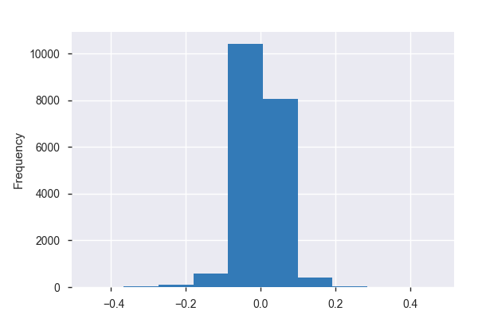

**Common Values**

| Value | Count | Frequency (%) |  |
| --- | --- | --- | --- |
| 0.07749850330231983 | 1 | 0.0% |  |
| 0.03559101574846955 | 1 | 0.0% |  |
| 0.010239779792447045 | 1 | 0.0% |  |
| 0.00037916983688821574 | 1 | 0.0% |  |
| 0.030083168056774884 | 1 | 0.0% |  |
| -0.08887291270708793 | 1 | 0.0% |  |
| 0.02782759801338638 | 1 | 0.0% |  |
| -0.028485486622795604 | 1 | 0.0% |  |
| 0.0021657897515585797 | 1 | 0.0% |  |
| 0.015186300454874284 | 1 | 0.0% |  |
| Other values (19612) | 19612 | 99.9% |  |

**Extreme Values**

Minimum 5 values

| Value | Count | Frequency (%) |  |
| --- | --- | --- | --- |
| -0.458752578777816 | 1 | 0.0% |  |
| -0.41310353508186726 | 1 | 0.0% |  |
| -0.3508895685397835 | 1 | 0.0% |  |
| -0.34627517131464297 | 1 | 0.0% |  |
| -0.33637427429889544 | 1 | 0.0% |  |

Maximum 5 values

| Value | Count | Frequency (%) |  |
| --- | --- | --- | --- |
| 0.30850721965357253 | 1 | 0.0% |  |
| 0.34090640096808805 | 1 | 0.0% |  |
| 0.36992343628626767 | 1 | 0.0% |  |
| 0.4028050468645292 | 1 | 0.0% |  |
| 0.4711637719997482 | 1 | 0.0% |  |

pitch_arm  
Numeric

| Distinct count | 19622 |
| --- | --- |
| Unique (%) | 100.0% |
| Missing (%) | 0.0% |
| Missing (n) | 0 |
| Infinite (%) | 0.0% |
| Infinite (n) | 0 |

| Mean | 2.8969e-18 |
| --- | --- |
| Minimum | -2.9281 |
| Maximum | 3.5426 |
| Zeros (%) | 0.0% |

Toggle details

**Statistics**

Quantile statistics

| Minimum | -2.9281 |
| --- | --- |
| 5-th percentile | -1.6214 |
| Q1 | -0.517 |
| Median | 0.047389 |
| Q3 | 0.53771 |
| 95-th percentile | 1.5445 |
| Maximum | 3.5426 |
| Range | 6.4707 |
| Interquartile range | 1.0547 |

Descriptive statistics

| Standard deviation | 0.89859 |
| --- | --- |
| Coef of variation | 3.1019e+17 |
| Kurtosis | 0.26787 |
| Mean | 2.8969e-18 |
| MAD | 0.69637 |
| Skewness | -0.14085 |
| Sum | 5.6843e-14 |
| Variance | 0.80747 |
| Memory size | 153.4 KiB |

**Histogram**

[figure not shown]

**Common Values**

| Value | Count | Frequency (%) |  |
| --- | --- | --- | --- |
| -1.8669763970229059 | 1 | 0.0% |  |
| -0.5454727885967441 | 1 | 0.0% |  |
| -1.7600280619020812 | 1 | 0.0% |  |
| -0.5615748542120089 | 1 | 0.0% |  |
| -0.5115568680068217 | 1 | 0.0% |  |
| 0.953378972439052 | 1 | 0.0% |  |
| 1.4831202387735827 | 1 | 0.0% |  |
| -0.6395927627548472 | 1 | 0.0% |  |
| 1.922867623225609 | 1 | 0.0% |  |
| 0.30813169149661795 | 1 | 0.0% |  |
| Other values (19612) | 19612 | 99.9% |  |

**Extreme Values**

Minimum 5 values

| Value | Count | Frequency (%) |  |
| --- | --- | --- | --- |
| -2.92806588971382 | 1 | 0.0% |  |
| -2.8950381099688793 | 1 | 0.0% |  |
| -2.8608360163688493 | 1 | 0.0% |  |
| -2.832540075997687 | 1 | 0.0% |  |
| -2.81672597032272 | 1 | 0.0% |  |

Maximum 5 values

| Value | Count | Frequency (%) |  |
| --- | --- | --- | --- |
| 2.9694446630369327 | 1 | 0.0% |  |
| 2.9846908571678283 | 1 | 0.0% |  |
| 3.004739307079118 | 1 | 0.0% |  |
| 3.2625550519748896 | 1 | 0.0% |  |
| 3.542621585442948 | 1 | 0.0% |  |

pitch_belt  
Numeric

| Distinct count | 19622 |
| --- | --- |
| Unique (%) | 100.0% |
| Missing (%) | 0.0% |
| Missing (n) | 0 |
| Infinite (%) | 0.0% |
| Infinite (n) | 0 |

| Mean | -6.9526e-17 |
| --- | --- |
| Minimum | -5.2728 |
| Maximum | 5.7923 |
| Zeros (%) | 0.0% |

Toggle details

**Statistics**

Quantile statistics

| Minimum | -5.2728 |
| --- | --- |
| 5-th percentile | -3.4013 |
| Q1 | -2.5052 |
| Median | -0.99558 |
| Q3 | 2.4768 |
| 95-th percentile | 4.3711 |
| Maximum | 5.7923 |
| Range | 11.065 |
| Interquartile range | 4.9819 |

Descriptive statistics

| Standard deviation | 2.6934 |
| --- | --- |
| Coef of variation | -3.8739e+16 |
| Kurtosis | -1.4959 |
| Mean | -6.9526e-17 |
| MAD | 2.5186 |
| Skewness | 0.18209 |
| Sum | -1.3642e-12 |
| Variance | 7.2542 |
| Memory size | 153.4 KiB |

**Histogram**

[figure not shown]

**Common Values**

| Value | Count | Frequency (%) |  |
| --- | --- | --- | --- |
| 3.328404891293725 | 1 | 0.0% |  |
| 2.3720491756746593 | 1 | 0.0% |  |
| -2.3590359039860105 | 1 | 0.0% |  |
| 2.3892662692265136 | 1 | 0.0% |  |
| 0.9739501504241039 | 1 | 0.0% |  |
| -3.1835493273425604 | 1 | 0.0% |  |
| -3.7319941647946773 | 1 | 0.0% |  |
| -3.41358578017541 | 1 | 0.0% |  |
| -3.936686206402306 | 1 | 0.0% |  |
| -2.536427110379878 | 1 | 0.0% |  |
| Other values (19612) | 19612 | 99.9% |  |

**Extreme Values**

Minimum 5 values

| Value | Count | Frequency (%) |  |
| --- | --- | --- | --- |
| -5.272791101850699 | 1 | 0.0% |  |
| -4.887054749778019 | 1 | 0.0% |  |
| -4.801722266136892 | 1 | 0.0% |  |
| -4.781754788722148 | 1 | 0.0% |  |
| -4.742458166769844 | 1 | 0.0% |  |

Maximum 5 values

| Value | Count | Frequency (%) |  |
| --- | --- | --- | --- |
| 5.563027841322956 | 1 | 0.0% |  |
| 5.645668918357034 | 1 | 0.0% |  |
| 5.654653442017047 | 1 | 0.0% |  |
| 5.689926910852987 | 1 | 0.0% |  |
| 5.792344121368438 | 1 | 0.0% |  |

pitch_dumbbell  
Numeric

| Distinct count | 19622 |
| --- | --- |
| Unique (%) | 100.0% |
| Missing (%) | 0.0% |
| Missing (n) | 0 |
| Infinite (%) | 0.0% |
| Infinite (n) | 0 |

| Mean | -1.4485e-17 |
| --- | --- |
| Minimum | -2.2315 |
| Maximum | 3.2419 |
| Zeros (%) | 0.0% |

Toggle details

**Statistics**

Quantile statistics

| Minimum | -2.2315 |
| --- | --- |
| 5-th percentile | -0.78863 |
| Q1 | -0.28928 |
| Median | -0.010415 |
| Q3 | 0.28122 |
| 95-th percentile | 0.83657 |
| Maximum | 3.2419 |
| Range | 5.4734 |
| Interquartile range | 0.5705 |

Descriptive statistics

| Standard deviation | 0.48276 |
| --- | --- |
| Coef of variation | -3.3329e+16 |
| Kurtosis | 0.92979 |
| Mean | -1.4485e-17 |
| MAD | 0.36946 |
| Skewness | 0.21331 |
| Sum | -2.8422e-13 |
| Variance | 0.23306 |
| Memory size | 153.4 KiB |

**Histogram**

[figure not shown]

**Common Values**

| Value | Count | Frequency (%) |  |
| --- | --- | --- | --- |
| 0.8574537316077913 | 1 | 0.0% |  |
| 0.6692394552626283 | 1 | 0.0% |  |
| -0.06429909133442044 | 1 | 0.0% |  |
| -0.15443472271250083 | 1 | 0.0% |  |
| 0.30862250464740754 | 1 | 0.0% |  |
| -0.12286921056884258 | 1 | 0.0% |  |
| 0.14299388346595152 | 1 | 0.0% |  |
| 0.1573063261530192 | 1 | 0.0% |  |
| -0.5895011826522457 | 1 | 0.0% |  |
| 0.09341394130146331 | 1 | 0.0% |  |
| Other values (19612) | 19612 | 99.9% |  |

**Extreme Values**

Minimum 5 values

| Value | Count | Frequency (%) |  |
| --- | --- | --- | --- |
| -2.231513807392821 | 1 | 0.0% |  |
| -2.115285415431296 | 1 | 0.0% |  |
| -2.0562249298637862 | 1 | 0.0% |  |
| -2.005081919047885 | 1 | 0.0% |  |
| -1.9295404498776412 | 1 | 0.0% |  |

Maximum 5 values

| Value | Count | Frequency (%) |  |
| --- | --- | --- | --- |
| 2.662941381822481 | 1 | 0.0% |  |
| 2.7161782965543377 | 1 | 0.0% |  |
| 2.8680513014626525 | 1 | 0.0% |  |
| 3.2242481033929296 | 1 | 0.0% |  |
| 3.2418913556697473 | 1 | 0.0% |  |

pitch_forearm  
Numeric

| Distinct count | 19622 |
| --- | --- |
| Unique (%) | 100.0% |
| Missing (%) | 0.0% |
| Missing (n) | 0 |
| Infinite (%) | 0.0% |
| Infinite (n) | 0 |

| Mean | -2.1727e-17 |
| --- | --- |
| Minimum | -2.3716 |
| Maximum | 2.9374 |
| Zeros (%) | 0.0% |

Toggle details

**Statistics**

Quantile statistics

| Minimum | -2.3716 |
| --- | --- |
| 5-th percentile | -0.29607 |
| Q1 | -0.089558 |
| Median | 0.0035655 |
| Q3 | 0.095281 |
| 95-th percentile | 0.27142 |
| Maximum | 2.9374 |
| Range | 5.309 |
| Interquartile range | 0.18484 |

Descriptive statistics

| Standard deviation | 0.19825 |
| --- | --- |
| Coef of variation | -9124600000000000 |
| Kurtosis | 12.498 |
| Mean | -2.1727e-17 |
| MAD | 0.13284 |
| Skewness | -0.015559 |
| Sum | -4.2633e-13 |
| Variance | 0.039303 |
| Memory size | 153.4 KiB |

**Histogram**

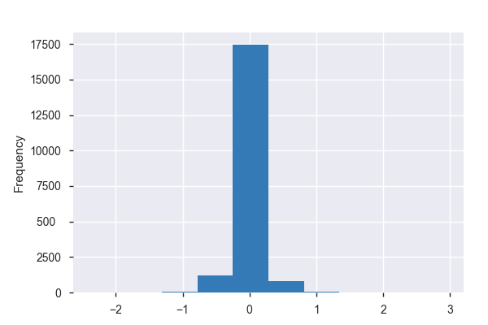

**Common Values**

| Value | Count | Frequency (%) |  |
| --- | --- | --- | --- |
| 0.045363155082574526 | 1 | 0.0% |  |
| -0.08959163830581608 | 1 | 0.0% |  |
| -0.1407318217122508 | 1 | 0.0% |  |
| -0.07350998982509266 | 1 | 0.0% |  |
| 0.24784034219196988 | 1 | 0.0% |  |
| 0.07600755089092405 | 1 | 0.0% |  |
| 0.2566949627765026 | 1 | 0.0% |  |
| 0.17947321368758284 | 1 | 0.0% |  |
| 0.19250159385361854 | 1 | 0.0% |  |
| -0.07161639536645327 | 1 | 0.0% |  |
| Other values (19612) | 19612 | 99.9% |  |

**Extreme Values**

Minimum 5 values

| Value | Count | Frequency (%) |  |
| --- | --- | --- | --- |
| -2.371586125604979 | 1 | 0.0% |  |
| -2.221151772884803 | 1 | 0.0% |  |
| -1.8588318969287898 | 1 | 0.0% |  |
| -1.5960257032969558 | 1 | 0.0% |  |
| -1.5575683090290076 | 1 | 0.0% |  |

Maximum 5 values

| Value | Count | Frequency (%) |  |
| --- | --- | --- | --- |
| 1.408962100918947 | 1 | 0.0% |  |
| 1.5201913258132103 | 1 | 0.0% |  |
| 1.9189879006205806 | 1 | 0.0% |  |
| 2.716024899203907 | 1 | 0.0% |  |
| 2.9373678678057997 | 1 | 0.0% |  |

roll_arm  
Numeric

| Distinct count | 19622 |
| --- | --- |
| Unique (%) | 100.0% |
| Missing (%) | 0.0% |
| Missing (n) | 0 |
| Infinite (%) | 0.0% |
| Infinite (n) | 0 |

| Mean | -1.4485e-17 |
| --- | --- |
| Minimum | -3.3878 |
| Maximum | 4.6533 |
| Zeros (%) | 0.0% |

Toggle details

**Statistics**

Quantile statistics

| Minimum | -3.3878 |
| --- | --- |
| 5-th percentile | -1.5761 |
| Q1 | -0.6085 |
| Median | 0.090269 |
| Q3 | 0.58347 |
| 95-th percentile | 1.4333 |
| Maximum | 4.6533 |
| Range | 8.0411 |
| Interquartile range | 1.192 |

Descriptive statistics

| Standard deviation | 0.92058 |
| --- | --- |
| Coef of variation | -6.3556e+16 |
| Kurtosis | 0.35563 |
| Mean | -1.4485e-17 |
| MAD | 0.72438 |
| Skewness | -0.14769 |
| Sum | -2.8422e-13 |
| Variance | 0.84747 |
| Memory size | 153.4 KiB |

**Histogram**

[figure not shown]

**Common Values**

| Value | Count | Frequency (%) |  |
| --- | --- | --- | --- |
| -0.18577582315973193 | 1 | 0.0% |  |
| 0.13845371073039475 | 1 | 0.0% |  |
| -1.103450628744649 | 1 | 0.0% |  |
| 0.4531318086037935 | 1 | 0.0% |  |
| 0.57035179003204 | 1 | 0.0% |  |
| 1.8392171765870127 | 1 | 0.0% |  |
| -1.1119134090554168 | 1 | 0.0% |  |
| -0.8185684543316921 | 1 | 0.0% |  |
| -1.3461706331389944 | 1 | 0.0% |  |
| 1.3140885777003068 | 1 | 0.0% |  |
| Other values (19612) | 19612 | 99.9% |  |

**Extreme Values**

Minimum 5 values

| Value | Count | Frequency (%) |  |
| --- | --- | --- | --- |
| -3.387799047183356 | 1 | 0.0% |  |
| -3.338615099108234 | 1 | 0.0% |  |
| -3.331482202650184 | 1 | 0.0% |  |
| -3.324924386936468 | 1 | 0.0% |  |
| -3.3187429545871816 | 1 | 0.0% |  |

Maximum 5 values

| Value | Count | Frequency (%) |  |
| --- | --- | --- | --- |
| 3.731218340036058 | 1 | 0.0% |  |
| 3.7666214045970197 | 1 | 0.0% |  |
| 3.768065167036647 | 1 | 0.0% |  |
| 3.778531399862335 | 1 | 0.0% |  |
| 4.653252563624974 | 1 | 0.0% |  |

roll_belt  
Numeric

| Distinct count | 19622 |
| --- | --- |
| Unique (%) | 100.0% |
| Missing (%) | 0.0% |
| Missing (n) | 0 |
| Infinite (%) | 0.0% |
| Infinite (n) | 0 |

| Mean | -3.4763e-17 |
| --- | --- |
| Minimum | -5.991 |
| Maximum | 6.9741 |
| Zeros (%) | 0.0% |

Toggle details

**Statistics**

Quantile statistics

| Minimum | -5.991 |
| --- | --- |
| 5-th percentile | -4.5468 |
| Q1 | -1.7748 |
| Median | 0.15259 |
| Q3 | 1.7916 |
| 95-th percentile | 4.7144 |
| Maximum | 6.9741 |
| Range | 12.965 |
| Interquartile range | 3.5664 |

Descriptive statistics

| Standard deviation | 2.7929 |
| --- | --- |
| Coef of variation | -8.034e+16 |
| Kurtosis | -0.7572 |
| Mean | -3.4763e-17 |
| MAD | 2.2579 |
| Skewness | -0.057478 |
| Sum | -6.8212e-13 |
| Variance | 7.8002 |
| Memory size | 153.4 KiB |

**Histogram**

[figure not shown]

**Common Values**

| Value | Count | Frequency (%) |  |
| --- | --- | --- | --- |
| 2.0604054458938372 | 1 | 0.0% |  |
| -1.1144908045344748 | 1 | 0.0% |  |
| 0.5374876719314333 | 1 | 0.0% |  |
| -1.1768783141993422 | 1 | 0.0% |  |
| -0.9838397063415372 | 1 | 0.0% |  |
| 1.6138622184181022 | 1 | 0.0% |  |
| -0.13576815985432572 | 1 | 0.0% |  |
| -1.3269499668940374 | 1 | 0.0% |  |
| 4.617270859369017 | 1 | 0.0% |  |
| -1.7175309088115467 | 1 | 0.0% |  |
| Other values (19612) | 19612 | 99.9% |  |

**Extreme Values**

Minimum 5 values

| Value | Count | Frequency (%) |  |
| --- | --- | --- | --- |
| -5.990959891086836 | 1 | 0.0% |  |
| -5.856803335969299 | 1 | 0.0% |  |
| -5.512615153491188 | 1 | 0.0% |  |
| -5.501710415303808 | 1 | 0.0% |  |
| -5.498717962201517 | 1 | 0.0% |  |

Maximum 5 values

| Value | Count | Frequency (%) |  |
| --- | --- | --- | --- |
| 6.146251526687353 | 1 | 0.0% |  |
| 6.346911203897078 | 1 | 0.0% |  |
| 6.458823152801209 | 1 | 0.0% |  |
| 6.533637121032359 | 1 | 0.0% |  |
| 6.974134048973114 | 1 | 0.0% |  |

roll_dumbbell  
Numeric

| Distinct count | 19622 |
| --- | --- |
| Unique (%) | 100.0% |
| Missing (%) | 0.0% |
| Missing (n) | 0 |
| Infinite (%) | 0.0% |
| Infinite (n) | 0 |

| Mean | 0 |
| --- | --- |
| Minimum | -2.066 |
| Maximum | 3.9489 |
| Zeros (%) | 0.0% |

Toggle details

**Statistics**

Quantile statistics

| Minimum | -2.066 |
| --- | --- |
| 5-th percentile | -0.83987 |
| Q1 | -0.30053 |
| Median | -0.012178 |
| Q3 | 0.29266 |
| 95-th percentile | 0.87494 |
| Maximum | 3.9489 |
| Range | 6.0148 |
| Interquartile range | 0.59319 |

Descriptive statistics

| Standard deviation | 0.51645 |
| --- | --- |
| Coef of variation |  |
| Kurtosis | 2.638 |
| Mean | 0 |
| MAD | 0.38524 |
| Skewness | 0.42227 |
| Sum | 0 |
| Variance | 0.26672 |
| Memory size | 153.4 KiB |

**Histogram**

[figure not shown]

**Common Values**

| Value | Count | Frequency (%) |  |
| --- | --- | --- | --- |
| -0.5879198928314474 | 1 | 0.0% |  |
| -0.15913019796690156 | 1 | 0.0% |  |
| -0.15271451380070813 | 1 | 0.0% |  |
| 0.48671162061442796 | 1 | 0.0% |  |
| -0.15448276497876443 | 1 | 0.0% |  |
| -0.06292098260877123 | 1 | 0.0% |  |
| 0.536257471308721 | 1 | 0.0% |  |
| -0.5558578337354003 | 1 | 0.0% |  |
| -0.3730591065868032 | 1 | 0.0% |  |
| -0.18533608615932595 | 1 | 0.0% |  |
| Other values (19612) | 19612 | 99.9% |  |

**Extreme Values**

Minimum 5 values

| Value | Count | Frequency (%) |  |
| --- | --- | --- | --- |
| -2.065969499982445 | 1 | 0.0% |  |
| -2.023409306608373 | 1 | 0.0% |  |
| -1.9701194143510803 | 1 | 0.0% |  |
| -1.9186333416025199 | 1 | 0.0% |  |
| -1.9185701700726894 | 1 | 0.0% |  |

Maximum 5 values

| Value | Count | Frequency (%) |  |
| --- | --- | --- | --- |
| 3.6287585925211503 | 1 | 0.0% |  |
| 3.645755037626196 | 1 | 0.0% |  |
| 3.69752912277221 | 1 | 0.0% |  |
| 3.7479779608330857 | 1 | 0.0% |  |
| 3.948869791933397 | 1 | 0.0% |  |

roll_forearm  
Numeric

| Distinct count | 19622 |
| --- | --- |
| Unique (%) | 100.0% |
| Missing (%) | 0.0% |
| Missing (n) | 0 |
| Infinite (%) | 0.0% |
| Infinite (n) | 0 |

| Mean | -4.3454e-18 |
| --- | --- |
| Minimum | -1.4256 |
| Maximum | 2.8316 |
| Zeros (%) | 0.0% |

Toggle details

**Statistics**

Quantile statistics

| Minimum | -1.4256 |
| --- | --- |
| 5-th percentile | -0.34944 |
| Q1 | -0.12397 |
| Median | 0.0064731 |
| Q3 | 0.12692 |
| 95-th percentile | 0.30942 |
| Maximum | 2.8316 |
| Range | 4.2572 |
| Interquartile range | 0.25089 |

Descriptive statistics

| Standard deviation | 0.23044 |
| --- | --- |
| Coef of variation | -5.3031e+16 |
| Kurtosis | 16.006 |
| Mean | -4.3454e-18 |
| MAD | 0.16177 |
| Skewness | 1.3446 |
| Sum | -8.5265e-14 |
| Variance | 0.053102 |
| Memory size | 153.4 KiB |

**Histogram**

[figure not shown]

**Common Values**

| Value | Count | Frequency (%) |  |
| --- | --- | --- | --- |
| 0.127847902603921 | 1 | 0.0% |  |
| -0.12492111335541185 | 1 | 0.0% |  |
| -0.04944804667361216 | 1 | 0.0% |  |
| -0.16416423103938665 | 1 | 0.0% |  |
| -0.16651578894341837 | 1 | 0.0% |  |
| -0.08719435046244589 | 1 | 0.0% |  |
| 0.003544890270682692 | 1 | 0.0% |  |
| -0.3431114326433602 | 1 | 0.0% |  |
| -0.2249570894768391 | 1 | 0.0% |  |
| 0.13343554248882952 | 1 | 0.0% |  |
| Other values (19612) | 19612 | 99.9% |  |

**Extreme Values**

Minimum 5 values

| Value | Count | Frequency (%) |  |
| --- | --- | --- | --- |
| -1.425577782136798 | 1 | 0.0% |  |
| -1.3327348931035632 | 1 | 0.0% |  |
| -1.2559980392315158 | 1 | 0.0% |  |
| -1.2020455300615562 | 1 | 0.0% |  |
| -1.1963316393045034 | 1 | 0.0% |  |

Maximum 5 values

| Value | Count | Frequency (%) |  |
| --- | --- | --- | --- |
| 2.515031382815844 | 1 | 0.0% |  |
| 2.515626703905021 | 1 | 0.0% |  |
| 2.5443804030095714 | 1 | 0.0% |  |
| 2.6264476298263704 | 1 | 0.0% |  |
| 2.8315987425713853 | 1 | 0.0% |  |

yaw_arm  
Numeric

| Distinct count | 19622 |
| --- | --- |
| Unique (%) | 100.0% |
| Missing (%) | 0.0% |
| Missing (n) | 0 |
| Infinite (%) | 0.0% |
| Infinite (n) | 0 |

| Mean | -2.8969e-17 |
| --- | --- |
| Minimum | -3.8482 |
| Maximum | 8.7874 |
| Zeros (%) | 0.0% |

Toggle details

**Statistics**

Quantile statistics

| Minimum | -3.8482 |
| --- | --- |
| 5-th percentile | -1.3065 |
| Q1 | -0.56997 |
| Median | -0.01697 |
| Q3 | 0.53485 |
| 95-th percentile | 1.4025 |
| Maximum | 8.7874 |
| Range | 12.636 |
| Interquartile range | 1.1048 |

Descriptive statistics

| Standard deviation | 0.87208 |
| --- | --- |
| Coef of variation | -3.0104e+16 |
| Kurtosis | 1.5416 |
| Mean | -2.8969e-17 |
| MAD | 0.6746 |
| Skewness | 0.35581 |
| Sum | -5.6843e-13 |
| Variance | 0.76053 |
| Memory size | 153.4 KiB |

**Histogram**

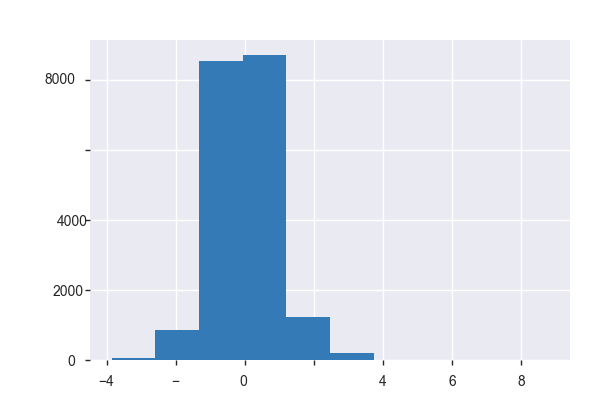

**Common Values**

| Value | Count | Frequency (%) |  |
| --- | --- | --- | --- |
| -0.2914128791612248 | 1 | 0.0% |  |
| 0.2913438793838221 | 1 | 0.0% |  |
| -1.5068581994312806 | 1 | 0.0% |  |
| -0.3648999701430219 | 1 | 0.0% |  |
| 0.8682355738842062 | 1 | 0.0% |  |
| 0.8054097649817391 | 1 | 0.0% |  |
| -0.322663095674465 | 1 | 0.0% |  |
| -0.6174844393209461 | 1 | 0.0% |  |
| 0.7502367175007468 | 1 | 0.0% |  |
| 0.15268875179077282 | 1 | 0.0% |  |
| Other values (19612) | 19612 | 99.9% |  |

**Extreme Values**

Minimum 5 values

| Value | Count | Frequency (%) |  |
| --- | --- | --- | --- |
| -3.848225331859388 | 1 | 0.0% |  |
| -3.8410417833865784 | 1 | 0.0% |  |
| -3.7964574348004696 | 1 | 0.0% |  |
| -3.5489093844118433 | 1 | 0.0% |  |
| -3.5096541001824644 | 1 | 0.0% |  |

Maximum 5 values

| Value | Count | Frequency (%) |  |
| --- | --- | --- | --- |
| 3.741602894776955 | 1 | 0.0% |  |
| 3.7978400700822847 | 1 | 0.0% |  |
| 3.849035362638493 | 1 | 0.0% |  |
| 3.8494897654276166 | 1 | 0.0% |  |
| 8.787374491810635 | 1 | 0.0% |  |

yaw_belt  
Numeric

| Distinct count | 19622 |
| --- | --- |
| Unique (%) | 100.0% |
| Missing (%) | 0.0% |
| Missing (n) | 0 |
| Infinite (%) | 0.0% |
| Infinite (n) | 0 |

| Mean | -4.6351e-17 |
| --- | --- |
| Minimum | -5.3387 |
| Maximum | 79.288 |
| Zeros (%) | 0.0% |

Toggle details

**Statistics**

Quantile statistics

| Minimum | -5.3387 |
| --- | --- |
| 5-th percentile | -3.2384 |
| Q1 | -1.5552 |
| Median | -0.28245 |
| Q3 | 1.5008 |
| 95-th percentile | 3.6063 |
| Maximum | 79.288 |
| Range | 84.627 |
| Interquartile range | 3.056 |

Descriptive statistics

| Standard deviation | 2.1339 |
| --- | --- |
| Coef of variation | -4.6037e+16 |
| Kurtosis | 96.338 |
| Mean | -4.6351e-17 |
| MAD | 1.7051 |
| Skewness | 2.8724 |
| Sum | -9.0949e-13 |
| Variance | 4.5534 |
| Memory size | 153.4 KiB |

**Histogram**

[figure not shown]

**Common Values**

| Value | Count | Frequency (%) |  |
| --- | --- | --- | --- |
| -2.006918788529323 | 1 | 0.0% |  |
| 2.131378478780444 | 1 | 0.0% |  |
| 0.3098187528897532 | 1 | 0.0% |  |
| -2.2563695094195615 | 1 | 0.0% |  |
| -0.5125765708604537 | 1 | 0.0% |  |
| 0.7490380666124128 | 1 | 0.0% |  |
| 4.404130007832592 | 1 | 0.0% |  |
| -0.468586861356994 | 1 | 0.0% |  |
| -1.5309540270735111 | 1 | 0.0% |  |
| -1.8079484728907673 | 1 | 0.0% |  |
| Other values (19612) | 19612 | 99.9% |  |

**Extreme Values**

Minimum 5 values

| Value | Count | Frequency (%) |  |
| --- | --- | --- | --- |
| -5.338674973417673 | 1 | 0.0% |  |
| -5.321266562296526 | 1 | 0.0% |  |
| -5.293327594364619 | 1 | 0.0% |  |
| -5.249982625883754 | 1 | 0.0% |  |
| -5.238744112370769 | 1 | 0.0% |  |

Maximum 5 values

| Value | Count | Frequency (%) |  |
| --- | --- | --- | --- |
| 6.624189607963528 | 1 | 0.0% |  |
| 6.797370132440752 | 1 | 0.0% |  |
| 6.807300771708733 | 1 | 0.0% |  |
| 6.869234549579164 | 1 | 0.0% |  |
| 79.28832516249045 | 1 | 0.0% |  |

yaw_dumbbell  
Numeric

| Distinct count | 19622 |
| --- | --- |
| Unique (%) | 100.0% |
| Missing (%) | 0.0% |
| Missing (n) | 0 |
| Infinite (%) | 0.0% |
| Infinite (n) | 0 |

| Mean | -5.7938e-18 |
| --- | --- |
| Minimum | -2.7627 |
| Maximum | 3.2542 |
| Zeros (%) | 0.0% |

Toggle details

**Statistics**

Quantile statistics

| Minimum | -2.7627 |
| --- | --- |
| 5-th percentile | -0.72374 |
| Q1 | -0.25388 |
| Median | 0.02064 |
| Q3 | 0.26337 |
| 95-th percentile | 0.68033 |
| Maximum | 3.2542 |
| Range | 6.0169 |
| Interquartile range | 0.51725 |

Descriptive statistics

| Standard deviation | 0.44804 |
| --- | --- |
| Coef of variation | -7.7331e+16 |
| Kurtosis | 2.9943 |
| Mean | -5.7938e-18 |
| MAD | 0.33181 |
| Skewness | -0.22946 |
| Sum | -1.1369e-13 |
| Variance | 0.20074 |
| Memory size | 153.4 KiB |

**Histogram**

[figure not shown]

**Common Values**

| Value | Count | Frequency (%) |  |
| --- | --- | --- | --- |
| -0.1572800485212093 | 1 | 0.0% |  |
| -0.056154945834113554 | 1 | 0.0% |  |
| 0.17011833849123395 | 1 | 0.0% |  |
| 0.028291098931311036 | 1 | 0.0% |  |
| -0.2898031039379236 | 1 | 0.0% |  |
| -0.0025349208493566544 | 1 | 0.0% |  |
| 0.02567122236211932 | 1 | 0.0% |  |
| -0.5398096039073619 | 1 | 0.0% |  |
| -0.7002413407171448 | 1 | 0.0% |  |
| -0.3390526673397739 | 1 | 0.0% |  |
| Other values (19612) | 19612 | 99.9% |  |

**Extreme Values**

Minimum 5 values

| Value | Count | Frequency (%) |  |
| --- | --- | --- | --- |
| -2.7627209097946634 | 1 | 0.0% |  |
| -2.7610350086968545 | 1 | 0.0% |  |
| -2.731836837796756 | 1 | 0.0% |  |
| -2.7145494072865333 | 1 | 0.0% |  |
| -2.7109026855684837 | 1 | 0.0% |  |

Maximum 5 values

| Value | Count | Frequency (%) |  |
| --- | --- | --- | --- |
| 2.7754835416386734 | 1 | 0.0% |  |
| 2.7927758649669827 | 1 | 0.0% |  |
| 2.827201873763102 | 1 | 0.0% |  |
| 3.0589292784342965 | 1 | 0.0% |  |
| 3.2541902802718985 | 1 | 0.0% |  |

yaw_forearm  
Numeric

| Distinct count | 19622 |
| --- | --- |
| Unique (%) | 100.0% |
| Missing (%) | 0.0% |
| Missing (n) | 0 |
| Infinite (%) | 0.0% |
| Infinite (n) | 0 |

| Mean | -5.4317e-18 |
| --- | --- |
| Minimum | -1.9828 |
| Maximum | 2.8776 |
| Zeros (%) | 0.0% |

Toggle details

**Statistics**

Quantile statistics

| Minimum | -1.9828 |
| --- | --- |
| 5-th percentile | -0.30139 |
| Q1 | -0.097358 |
| Median | 0.0085935 |
| Q3 | 0.1027 |
| 95-th percentile | 0.28398 |
| Maximum | 2.8776 |
| Range | 4.8604 |
| Interquartile range | 0.20006 |

Descriptive statistics

| Standard deviation | 0.19161 |
| --- | --- |
| Coef of variation | -3.5276e+16 |
| Kurtosis | 11.252 |
| Mean | -5.4317e-18 |
| MAD | 0.13573 |
| Skewness | -0.036293 |
| Sum | -1.0658e-13 |
| Variance | 0.036714 |
| Memory size | 153.4 KiB |

**Histogram**

[figure not shown]

**Common Values**

| Value | Count | Frequency (%) |  |
| --- | --- | --- | --- |
| -0.281897512944549 | 1 | 0.0% |  |
| -0.10396421352618149 | 1 | 0.0% |  |
| 0.04488251876721298 | 1 | 0.0% |  |
| -0.04385010920184713 | 1 | 0.0% |  |
| -0.11002935013024735 | 1 | 0.0% |  |
| 0.15497899239757779 | 1 | 0.0% |  |
| -0.17060570259105845 | 1 | 0.0% |  |
| 0.06505142509297827 | 1 | 0.0% |  |
| -0.01596563247108501 | 1 | 0.0% |  |
| -0.05844012315725907 | 1 | 0.0% |  |
| Other values (19612) | 19612 | 99.9% |  |

**Extreme Values**

Minimum 5 values

| Value | Count | Frequency (%) |  |
| --- | --- | --- | --- |
| -1.982801841917007 | 1 | 0.0% |  |
| -1.5727471943257203 | 1 | 0.0% |  |
| -1.5421799224599602 | 1 | 0.0% |  |
| -1.518186942170323 | 1 | 0.0% |  |
| -1.4614567923744717 | 1 | 0.0% |  |

Maximum 5 values

| Value | Count | Frequency (%) |  |
| --- | --- | --- | --- |
| 1.6746139205489066 | 1 | 0.0% |  |
| 2.14786468847776 | 1 | 0.0% |  |
| 2.27465587438722 | 1 | 0.0% |  |
| 2.5948075663297177 | 1 | 0.0% |  |
| 2.8775997535361184 | 1 | 0.0% |  |

# Sample

|  | roll_belt | pitch_belt | yaw_belt | gyros_belt_x | gyros_belt_y | gyros_belt_z | accel_belt_x | accel_belt_y | accel_belt_z | magnet_belt_x | magnet_belt_y | magnet_belt_z | roll_arm | pitch_arm | yaw_arm | gyros_arm_x | gyros_arm_y | gyros_arm_z | accel_arm_x | accel_arm_y | accel_arm_z | magnet_arm_x | magnet_arm_y | magnet_arm_z | roll_dumbbell | pitch_dumbbell | yaw_dumbbell | gyros_dumbbell_x | gyros_dumbbell_y | … |
| --- | --- | --- | --- | --- | --- | --- | --- | --- | --- | --- | --- | --- | --- | --- | --- | --- | --- | --- | --- | --- | --- | --- | --- | --- | --- | --- | --- | --- | --- | --- |
| 0 | -2.167559 | 3.482042 | -2.562836 | 0.939136 | -1.458998 | -1.900957 | -0.127768 | -2.890563 | -1.299082 | -0.685201 | -1.844881 | 0.204754 | 0.489405 | 1.966382 | 0.380533 | -0.613762 | -0.458710 | -0.079085 | 1.384155 | 0.633121 | -0.035747 | 0.399394 | -0.144556 | -0.135851 | 0.942646 | 0.035598 | 0.009308 | 0.070160 | -0.163040 | … |
| 1 | -2.185010 | 3.523464 | -2.561469 | 0.941947 | -1.542805 | -1.967037 | -0.174073 | -2.834902 | -1.316004 | -0.707816 | -1.765074 | 0.305388 | 0.477669 | 1.980649 | 0.318971 | -0.599194 | -0.435923 | -0.124037 | 1.378043 | 0.578436 | 0.002099 | 0.383406 | -0.109087 | -0.153862 | 0.946233 | 0.037783 | -0.025678 | -0.083737 | -0.141536 | … |
| 2 | -2.196635 | 3.487823 | -2.566473 | 0.940748 | -1.468584 | -1.905819 | -0.153960 | -2.852400 | -1.319248 | -0.695899 | -1.789419 | 0.275985 | 0.483679 | 1.966115 | 0.366648 | -0.611469 | -0.452367 | -0.082981 | 1.382440 | 0.605000 | -0.015711 | 0.382866 | -0.156690 | -0.106635 | 0.965452 | 0.050039 | 0.015935 | 0.123890 | -0.162764 | … |
| 3 | -2.192600 | 3.503097 | -2.551337 | 0.938222 | -1.484106 | -1.945207 | -0.187830 | -2.818105 | -1.323642 | -0.709418 | -1.812462 | 0.289311 | 0.490198 | 1.950516 | 0.302688 | -0.613327 | -0.425628 | -0.099271 | 1.367149 | 0.580619 | -0.042587 | 0.417265 | -0.151962 | -0.136848 | 0.947366 | 0.017190 | -0.013386 | -0.004296 | -0.149630 | … |
| 4 | -2.250723 | 3.477962 | -2.528180 | 0.929272 | -1.501089 | -1.982851 | -0.199214 | -2.846884 | -1.296027 | -0.743796 | -1.705684 | 0.222948 | 0.458591 | 1.967104 | 0.396833 | -0.548244 | -0.451170 | -0.114469 | 1.362344 | 0.607925 | -0.039873 | 0.385361 | -0.141785 | -0.125712 | 0.974467 | 0.042059 | -0.042541 | 0.169826 | -0.155174 | … |